# The Mitchell Model Explained

CDFW - Bay Delta

July 7, 2015

## Background

To better understand young-of-the-year recruitment for White Sturgeon, we (CDFW) solicited the help of US Fish and Wildlife Service (USFWS) mathematical statisticians Lara Mitchell and Ken Newman. Lara Mitchell (LM) developed a model for estimating a recruitment index for White Sturgeon. The inner workings of this model are documented herein. Also, model output is assessed by varying the input passed to model parameters.

Data used to develop this model came from the following sources.

- CDFW mark-recapture (tagging)
- Sturgeon Report Card (angler-reported length data)
- White Sturgeon age-length (from 2014 mark-recapture and 2014 sturgeon fishing derby;  
  samples collected and aged by USFWS personnel)

Other resources

- See Kimura and Chikuni (1987)
- LM book reference for age-length key Book Reference

## The Age-Length Data

- Artificial age-length from Bay Study Otter Trawl
- Age-length data from CDFW tagging and sturgeon fishing derby (sampling by USFWS)

LM combined these three data sets to make an age-length key that covers a larger length range than would be covered by any one of the three alone.

```r
# Artifical age-length points coming from the Bay Study Otter Trawl age-month
# key. I think that key is based on total length, so convert to fork length
# using the formula Jason sent before.

#OtterAge <- c(rep(0,12), rep(1,12))

OtterAge <- c(1/12, 2/12, 3/12, 4/12, 5/12, 6/12, 7/12, 8/12, 9/12, 10/12,
              11/12, 1, 1 + 1/12, 1 + 2/12, 1 + 3/12, 1 + 4/12, 1 + 5/12,
              1 + 6/12, 1 + 7/12, 1 + 8/12, 1 + 9/12, 1 + 10/12, 1 + 11/12,
              1 + 12/12)

OtterTotalLength <- c(8, 8, 8, 8, 16, 20, 24, 28, 32, 34, 36, 38,
                      38, 39, 40, 41, 42, 44, 46, 48, 50, 51, 52, 53)

OtterForkLength <- (0.9036 * OtterTotalLength) - 1.2162

BayStudyOtterTrawlKey <- data.frame(
  "Year" = NA,
  "ForkLength" = OtterForkLength,
  "Age" = OtterAge,
  "BroodYear" = NA,
  "ln_ForkLength" = log(OtterForkLength), # natural log
  "Source" = "OtterTrawlKey",
  stringsAsFactors = FALSE
)

#BayStudyOtterTrawlKey
```

```r
###### Clean 2014 Age-Length Data:
# Double check that the forklengths are in cm.
agelen_orig <- read.csv(paste0(wsroot,"USFWSWSTDataAgeLen.csv"), header=TRUE,
                        stringsAsFactors=FALSE)

agelenData <- agelen_orig
agelenData$Year <- 2014      # as a reminder
agelenData$BroodYear <- with(agelenData, Year - Age)
agelenData$ln_ForkLength <- log(agelenData$ForkLength)

agelenData <- agelenData[ ,c("Year","ForkLength","Age","BroodYear",
                              "ln_ForkLength","Source")]

# Combine agelenData and BayStudyOtterTrawlKey. If you don't want to use
# BayStudyOtterTrawlKey, just comment the whole thing out above.
if(exists("BayStudyOtterTrawlKey")) {
  agelenData <- rbind(BayStudyOtterTrawlKey, agelenData)
}

# Sort by Age, ForkLength, and Year:
agelenData <- agelenData[with(agelenData, order(Age,ForkLength,Year)), ]
```

Below are data (sorted by age, fork length, and then year) used to create age-length key.

```
    Year ForkLength         Age BroodYear ln_ForkLength        Source
1     NA     6.0126  0.08333333        NA      1.793857 OtterTrawlKey
2     NA     6.0126  0.16666667        NA      1.793857 OtterTrawlKey
3     NA     6.0126  0.25000000        NA      1.793857 OtterTrawlKey
4     NA     6.0126  0.33333333        NA      1.793857 OtterTrawlKey
5     NA    13.2414  0.41666667        NA      2.583348 OtterTrawlKey
6     NA    16.8558  0.50000000        NA      2.824695 OtterTrawlKey
7     NA    20.4702  0.58333333        NA      3.018970 OtterTrawlKey
8     NA    24.0846  0.66666667        NA      3.181573 OtterTrawlKey
9     NA    27.6990  0.75000000        NA      3.321396 OtterTrawlKey
10    NA    29.5062  0.83333333        NA      3.384600 OtterTrawlKey
11    NA    31.3134  0.91666667        NA      3.444046 OtterTrawlKey
12    NA    33.1206  1.00000000        NA      3.500155 OtterTrawlKey
13    NA    33.1206  1.08333333        NA      3.500155 OtterTrawlKey
14    NA    34.0242  1.16666667        NA      3.527072 OtterTrawlKey
```

[output cut: 231 more lines]

## Testing Data

- CDFW Tagging (1990, 1991, 1993, 1994, 1997, 1998, 2001, 2002, 2005-2014)
- Sturgeon Report Card Data (2007-2014)

```r
###### Clean Card Data:

# The original file contains all white sturgeon reported, regardless of whether
# or not the fork length was also reported. The legal slot limit is ~ 102 to 152
# cm. Remove fish with fork length < 12 INCHES = 30.48 cm, per Jason's email.
# These are probably not accurate lengths (may accidentally be catches recorded
# in the wrong spot on the report card).

card_orig <- read.csv(paste0(wsroot,"WST_Card.csv"), header=TRUE,
                      stringsAsFactors=FALSE)

# Each record represents one fish:
card_tmp <- subset(card_orig, !is.na(FL_cm) & FL_in >= 12)
card_tmp$ForkLength <- card_tmp$FL_cm
card_tmp$Count <- 1       # just a place holder for use in aggregate()

# Each record represents a different catchYear-forkLength:
cardData <- aggregate(card_tmp[ ,"Count",drop=FALSE],
                      by=card_tmp[ ,c("ForkLength","Year")],
                      FUN=sum)

# Reorder the columns
cardData <- cardData[ ,c("Year","ForkLength","Count")]
# set new row names
row.names(cardData) <- with(cardData, paste(Year,ForkLength,sep="."))

# Show some of orginal card data (J. DuBois added 06-Jul-2015)
card_orig[seq(from = 1, to = nrow(card_orig), by = 5000), ]
```

```
      Year SturgeonType CatchType Length FL_in FL_cm
1     2007        White      Kept     40    36    91
5001  2009        White      Kept     65    58   147
10001 2012        White      Kept     62    56   142
15001 2007        White  Released     74    67   170
20001 2008        White  Released     NA    NA    NA
25001 2009        White  Released     36    32    81
30001 2009        White  Released     NA    NA    NA
35001 2011        White  Released     35    31    79
40001 2012        White  Released     NA    NA    NA
45001 2013        White  Released     NA    NA    NA
50001 2014        White  Released     NA    NA    NA
```

```r
###### Clean Tagging Data:

tagging_orig <- read.csv(paste0(wsroot,"WST_Tagging.csv"), header=TRUE,
                         stringsAsFactors=FALSE)

# Adding restraint on length because using gear selectivity model on small
# lengths (where n is low) results in exceptionally high n after 'adjustment'
# (J. DuBois, 06-Jul-2015) --- not working
#tagging_orig <- tagging_orig[tagging_orig$TL_cm > 84, ]

# from Jason's email
tagging_orig$FL_cm <- (0.9036 * tagging_orig$TL_cm) - 1.2162

# tagging_orig has a separate count record for each unique
# catchYear-totalLength. Round calculated forkLengths to the nearest integer,
# then re-tabulate based on unique catchYear-forkLength:
tagging_tmp <- tagging_orig
tagging_tmp$Count <- round(tagging_tmp$AdjCatch)
tagging_tmp$ForkLength <- round(tagging_tmp$FL_cm)

# Each record represents a different catchYear-forkLength:
taggingData <- aggregate(tagging_tmp[,"Count",drop=FALSE],
                          by=tagging_tmp[ ,c("ForkLength","Year")],
                          FUN=sum)

# Reorder the columns
taggingData <- taggingData[ ,c("Year","ForkLength","Count")]
# set new row names
row.names(taggingData) <- with(taggingData, paste(Year,ForkLength,sep="."))

# Show some of orginal tagging data (J. DuBois added 06-Jul-2015)
tagging_orig[seq(from = 1, to = nrow(tagging_orig), by = 200), ]
```

```
     Year TL_cm LenCat Mesh6 Mesh7 Mesh8 adj.Mesh6 adj.Mesh7 adj.Mesh8
1    1990    70    sub     1     0     0 12.035641  0.000000  0.000000
201  1991   157    leg     0     0     2  0.000000  0.000000  3.657449
401  1994   158    leg     0     0     1  0.000000  0.000000  1.840227
601  1998   165    leg     2     5     1  8.740297 18.942825  1.881024
801  2002   131    leg     2     2     6  7.526115  6.749823  6.619596
1001 2006   140    leg     1     0     4  3.777964  0.000000  5.489211
1201 2008    88    sub     1     1     0  2.087775  5.343738  0.000000
1401 2009   163    leg     2     0     1  8.580215  0.000000  1.875146
1601 2011   122    leg     1     1     4  3.747597  2.705077  4.000000
1801 2013    97    sub     4     2     0  8.550532  5.122097  0.000000
     Catch  AdjCatch    FL_cm
1        1 12.035641  62.0358
201      2  3.657449 140.6490
401      1  1.840227 141.5526
601      8 29.564146 147.8778
801     10 20.895534 117.1554
1001     5  9.267176 125.2878
1201     2  7.431513  78.3006
1401     3 10.455362 146.0706
1601     6 10.452674 109.0230
1801     6 13.672629  86.4330
```

```r
# Create a data set containing both Card and Tagging Data:
both_tmp <- rbind(cardData, taggingData)

# Each record represents a different catchYear-forkLength:
bothData <- aggregate(both_tmp[,"Count",drop=FALSE],
                        by=both_tmp[ ,c("ForkLength","Year")],
                        FUN=sum)

# Reorder the columns
bothData <- bothData[ ,c("Year","ForkLength","Count")]
# set new row names
row.names(bothData) <- with(bothData, paste(Year,ForkLength,sep="."))
```

## Sacramento Water-Year Index Data

Data from [California Data Exchange Center](http://cdec.water.ca.gov/cgi-progs/iodir/wsihist) (find “WY Index”)

```r
####### Water Year Index:

# Loads: Sac_H20_Index
#        SJ_H20_Index
#        Sac_H20_Index_adj
#        SJ_H20_Index_adj

# water year data
Sac_H20_Index
```

```
 1906  1907  1908  1909  1910  1911  1912  1913  1914  1915  1916  1917
11.76 14.07  7.73 12.10  9.38 11.74  6.71  6.24 10.92 10.99 10.83  8.83
 1918  1919  1920  1921  1922  1923  1924  1925  1926  1927  1928  1929
 6.19  7.00  5.15  9.20  8.97  7.06  3.87  6.39  5.75  9.52  8.27  5.22
 1930  1931  1932  1933  1934  1935  1936  1937  1938  1939  1940  1941
 5.90  3.66  5.48  4.63  4.07  6.98  7.75  6.87 12.62  5.58  8.88 11.47
 1942  1943  1944  1945  1946  1947  1948  1949  1950  1951  1952  1953
11.27  9.77  6.35  6.80  7.70  5.61  7.12  6.09  6.62  9.18 12.38  9.55
 1954  1955  1956  1957  1958  1959  1960  1961  1962  1963  1964  1965
 8.51  6.14 11.38  7.83 12.16  6.75  6.20  5.68  6.65  9.63  6.41 10.15
 1966  1967  1968  1969  1970  1971  1972  1973  1974  1975  1976  1977
 7.16 10.20  7.24 11.05 10.40 10.37  7.29  8.58 12.99  9.35  5.29  3.11
 1978  1979  1980  1981  1982  1983  1984  1985  1986  1987  1988  1989
 8.65  6.67  9.04  6.21 12.76 15.29 10.00  6.47  9.96  5.86  4.65  6.13
 1990  1991  1992  1993  1994  1995  1996  1997  1998  1999  2000  2001
 4.81  4.21  4.06  8.54  5.02 12.89 10.26 10.82 13.31  9.80  8.94  5.76
 2002  2003  2004  2005  2006  2007  2008  2009  2010  2011  2012  2013
 6.35  8.21  7.51  8.49 13.20  6.19  5.16  5.78  7.08 10.54  6.89  5.83
 2014
 4.08
```

```r
SJ_H20_Index
```

```
1906 1907 1908 1909 1910 1911 1912 1913 1914 1915 1916 1917 1918 1919 1920
6.70 6.20 2.40 4.59 3.65 5.97 2.55 2.00 4.35 4.10 4.65 4.13 3.08 2.62 2.64
1921 1922 1923 1924 1925 1926 1927 1928 1929 1930 1931 1932 1933 1934 1935
3.23 4.54 3.55 1.42 2.93 2.30 3.56 2.63 2.00 2.02 1.20 3.41 2.44 1.44 3.56
1936 1937 1938 1939 1940 1941 1942 1943 1944 1945 1946 1947 1948 1949 1950
3.74 3.90 5.89 2.20 3.36 4.43 4.44 4.03 2.76 3.59 3.30 2.18 2.70 2.53 2.85
1951 1952 1953 1954 1955 1956 1957 1958 1959 1960 1961 1962 1963 1964 1965
3.14 5.17 3.03 2.72 2.30 4.46 3.01 4.77 2.21 1.85 1.38 3.07 3.57 2.19 3.81
1966 1967 1968 1969 1970 1971 1972 1973 1974 1975 1976 1977 1978 1979 1980
2.51 5.25 2.21 6.09 3.18 2.89 2.16 3.50 3.90 3.85 1.57 0.84 4.58 3.67 4.73
1981 1982 1983 1984 1985 1986 1987 1988 1989 1990 1991 1992 1993 1994 1995
2.44 5.45 7.22 3.69 2.40 4.31 1.86 1.48 1.96 1.51 1.96 1.56 4.20 2.05 5.95
1996 1997 1998 1999 2000 2001 2002 2003 2004 2005 2006 2007 2008 2009 2010
4.12 4.13 5.65 3.59 3.38 2.20 2.34 2.81 2.21 4.75 5.90 1.97 2.06 2.72 3.55
2011 2012 2013 2014
5.58 2.18 1.71 1.16
```

```r
Sac_H20_Index_adj
```

```
 1905  1906  1907  1908  1909  1910  1911  1912  1913  1914  1915  1916
11.76 14.07  7.73 12.10  9.38 11.74  6.71  6.24 10.92 10.99 10.83  8.83
 1917  1918  1919  1920  1921  1922  1923  1924  1925  1926  1927  1928
 6.19  7.00  5.15  9.20  8.97  7.06  3.87  6.39  5.75  9.52  8.27  5.22
 1929  1930  1931  1932  1933  1934  1935  1936  1937  1938  1939  1940
 5.90  3.66  5.48  4.63  4.07  6.98  7.75  6.87 12.62  5.58  8.88 11.47
 1941  1942  1943  1944  1945  1946  1947  1948  1949  1950  1951  1952
11.27  9.77  6.35  6.80  7.70  5.61  7.12  6.09  6.62  9.18 12.38  9.55
 1953  1954  1955  1956  1957  1958  1959  1960  1961  1962  1963  1964
 8.51  6.14 11.38  7.83 12.16  6.75  6.20  5.68  6.65  9.63  6.41 10.15
 1965  1966  1967  1968  1969  1970  1971  1972  1973  1974  1975  1976
 7.16 10.20  7.24 11.05 10.40 10.37  7.29  8.58 12.99  9.35  5.29  3.11
 1977  1978  1979  1980  1981  1982  1983  1984  1985  1986  1987  1988
 8.65  6.67  9.04  6.21 12.76 15.29 10.00  6.47  9.96  5.86  4.65  6.13
 1989  1990  1991  1992  1993  1994  1995  1996  1997  1998  1999  2000
 4.81  4.21  4.06  8.54  5.02 12.89 10.26 10.82 13.31  9.80  8.94  5.76
 2001  2002  2003  2004  2005  2006  2007  2008  2009  2010  2011  2012
 6.35  8.21  7.51  8.49 13.20  6.19  5.16  5.78  7.08 10.54  6.89  5.83
 2013
 4.08
```

```r
SJ_H20_Index_adj
```

```
1905 1906 1907 1908 1909 1910 1911 1912 1913 1914 1915 1916 1917 1918 1919
6.70 6.20 2.40 4.59 3.65 5.97 2.55 2.00 4.35 4.10 4.65 4.13 3.08 2.62 2.64
1920 1921 1922 1923 1924 1925 1926 1927 1928 1929 1930 1931 1932 1933 1934
3.23 4.54 3.55 1.42 2.93 2.30 3.56 2.63 2.00 2.02 1.20 3.41 2.44 1.44 3.56
1935 1936 1937 1938 1939 1940 1941 1942 1943 1944 1945 1946 1947 1948 1949
3.74 3.90 5.89 2.20 3.36 4.43 4.44 4.03 2.76 3.59 3.30 2.18 2.70 2.53 2.85
1950 1951 1952 1953 1954 1955 1956 1957 1958 1959 1960 1961 1962 1963 1964
3.14 5.17 3.03 2.72 2.30 4.46 3.01 4.77 2.21 1.85 1.38 3.07 3.57 2.19 3.81
1965 1966 1967 1968 1969 1970 1971 1972 1973 1974 1975 1976 1977 1978 1979
2.51 5.25 2.21 6.09 3.18 2.89 2.16 3.50 3.90 3.85 1.57 0.84 4.58 3.67 4.73
1980 1981 1982 1983 1984 1985 1986 1987 1988 1989 1990 1991 1992 1993 1994
2.44 5.45 7.22 3.69 2.40 4.31 1.86 1.48 1.96 1.51 1.96 1.56 4.20 2.05 5.95
1995 1996 1997 1998 1999 2000 2001 2002 2003 2004 2005 2006 2007 2008 2009
4.12 4.13 5.65 3.59 3.38 2.20 2.34 2.81 2.21 4.75 5.90 1.97 2.06 2.72 3.55
2010 2011 2012 2013
5.58 2.18 1.71 1.16
```

## Using Age-Length Key to Assign Ages

This step uses the function `ageAssignResults`. The inputs to this function are described by LM below (from file “WS_broodcomp_run.r”).

> Using an Age-Length Key to assign ages to California white sturgeon for which only lengths are available, and use the number-at-age to estimate recruitment indices.

For further info, read LM’s comments below. The age-length key used can be either raw or iterated. Also, a one can use a growth model when selecting an iterated age-length key. These concepts of the age-length key (raw or iterated) and use of a growth model will be explored further later in this report.

```r
# LM's comments below *************************************************

## Summary of the inputs to ageAssignResults:
##
## lenDataSource: "Tagging", "Card", or "Both"
## alkType: "Raw" or "Iterated"
## growthModelType: "VB.Normal", "VB.LogNormal", "Gompertz.Normal",
##                    "Gompertz.LogNormal", or ""
##
## If alkType is "Raw", a growth model isn't used, so the input
##   growthModelType is ignored.
## If alkType is "Iterated", either choose to NOT use a growth model
##   by using growthModelType="" (in which case the inverse ALK is
##   constructed directly from the age-length data), or choose to use
##   a growth model by using a non-empty string.
##
## lengthBinVec and ageBinVec have the structure:
##              c(min, practicalMax, absoluteMax, stepSize)
##
## ageAssignResults() returns a lot of things, and you can add
##   or remove items to/from the return list. The items commonly
##   needed for plotting and modeling are saved in the variables below,
##   e.g., selectSource, year.catch, etc.
##
## I use things like usedevnew to go back and forth between plotting
## in R and saving multiple plots in a pdf.

# ******************************************************************************

myResults <- ageAssignResults(
  lenDataSource="Tagging", lengthBinVec=c(0,300,310,5),
  ageBinVec=c(0,50,70,1), alkType="Iterated", growthModelType=""
  )

# assign some of the results of myResults to variables for further testing
selectSource <- myResults[["lenDataSource"]]
year.catch <- myResults[["year.catch"]]
year.catch.char <- as.character(year.catch)

year.brood <- myResults[["year.brood"]]
year.brood.char <- as.character(year.brood)
nYearBrood <- length(year.brood)

nAgeList <- myResults[["nAgeList"]]
broodList <- myResults[["broodList"]]
nBYxCY <- myResults[["nBYxCY"]]
nBY <- myResults[["nBY"]]
nBYxAgeWide <- myResults[["nBYxAgeWide"]]
nBYxAgeLong <- myResults[["nBYxAgeLong"]]
lenBinnedWide <- myResults[["lenBinnedWide"]]

ALK <- myResults[["alkList"]][[1]]
```

*My Note*: Throughout her code, LM saves some plots to pdf. Those plots that would be saved to a pdf are included in this report. Also, any reference in LM’s code to “usedevnew” has been removed herein, as all plots are included in this report (rather than as separate file).

## Figures

### nBYxCY

Figure below plots “nBYxCY,” which is number of fish per brood year (BY) with catch year (CY) identified by color.

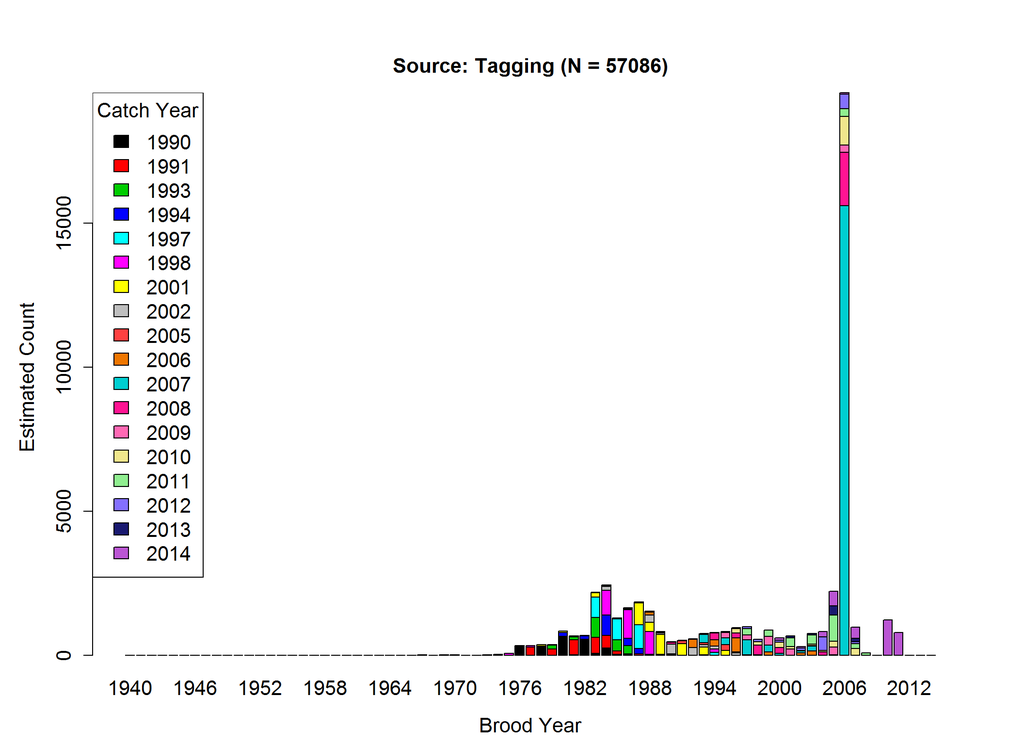

```r
# graphical settings
par(mfcol=c(1,1), mar=c(4.5,5,3,2), oma=c(0,0,2,1),
    cex.axis=1.3, cex.lab=1.3, cex.main=1.3)

## Plot catch year composition for each brood year:
barplot(t(nBYxCY), col=catchYrCol, xlab="Brood Year", ylab="Estimated Count",
          main=paste0("Source: ",selectSource," (N = ",sum(lenBinnedWide),")"))
legend("topleft", year.catch.char, fill=catchYrCol, title="Catch Year", cex=1.3)
```

### Sac Water-Year Index

Figure below plots the Sacramento Water-Year Index for the brood years.

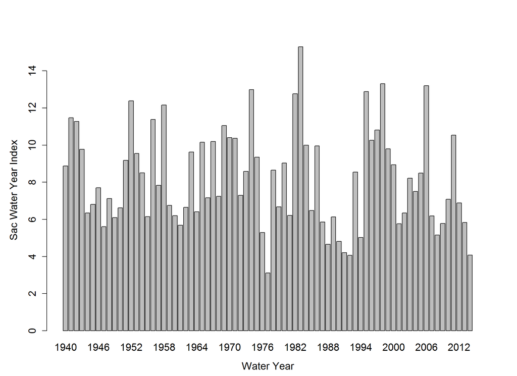

```r
# graphical settings
par(mfcol=c(1,1), mar=c(4.5,5,3,2), oma=c(0,0,2,1),
    cex.axis=1.3, cex.lab=1.3, cex.main=1.3)

# plot Sac WY Index for only the brood years
barplot(Sac_H20_Index[as.character(year.brood)], xlab="Water Year",
        ylab="Sac Water Year Index")
```

### Exponential model

Fit exponential model

```r
## Fit exponential model to the number-at-age by brood year:
myFit <- fitExpModel(resultObject=myResults, bySubsetVec=c(1970:2013),
                     formulaOpt=4, usedevnew=usedevnew, plotBool=FALSE)
```

```
## N0S0:
##         1970         1971         1972         1973         1974
## 3.824757e+03 3.807522e+03 1.736969e+03 2.204325e+03 9.590861e+03
##         1975         1976         1977         1978         1979
## 1.947891e+04 7.433686e+03 1.276067e+04 1.384200e+04 7.166828e+03
##         1980         1981         1982         1983         1984
## 9.485821e+03 4.235325e+03 3.994165e+03 1.567682e+04 1.604690e+04
##         1985         1986         1987         1988         1989
## 5.635750e+03 9.011826e+03 1.046732e+04 1.103096e+04 6.808549e+03
##         1990         1991         1992         1993         1994
## 6.152003e+03 4.977261e+03 6.412434e+03 4.886032e+03 4.422412e+03
##         1995         1996         1997         1998         1999
## 5.738919e+03 3.910358e+03 5.938062e+03 3.228488e+03 3.470895e+03
##         2000         2001         2002         2003         2004
## 2.677091e+03 2.884245e+03 8.665636e+02 8.499313e+02 2.352878e+03
##         2005         2006         2007         2008         2009
## 3.016361e+03 4.709683e+03 1.049815e+03 1.731921e+02 6.270398e-12
##         2010         2011         2012         2013
## 3.938360e+03 1.879344e+03 1.167920e-08 3.349026e-07
##
## lambda: 0.2999476
## AIC: 2936.603
```

### N0S0

Plot N0S0 (explained further later in this report) from the model fit above

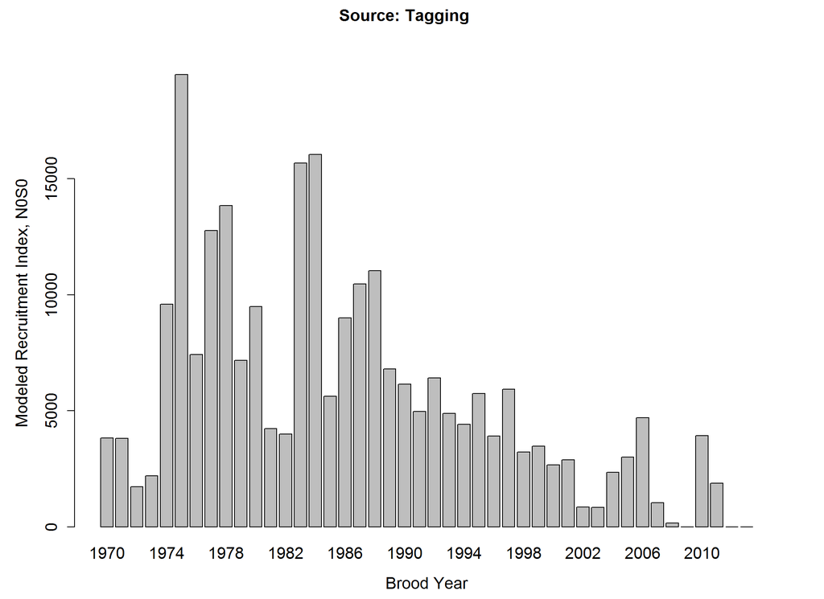

```r
# graphical settings
par(mfcol=c(1,1), mar=c(4.5,5,3,2), oma=c(0,0,2,1),
    cex.axis=1.3, cex.lab=1.3, cex.main=1.3)

# Barplot of N0S0:
barplot(myFit[["N0S0"]], xlab="Brood Year",
        ylab="Modeled Recruitment Index, N0S0")
title(main=paste("Source:",myResults[["lenDataSource"]]),
      outer=-1, cex=1.5)
```

### Modeled Recruitment index

Should code below plot two plots?

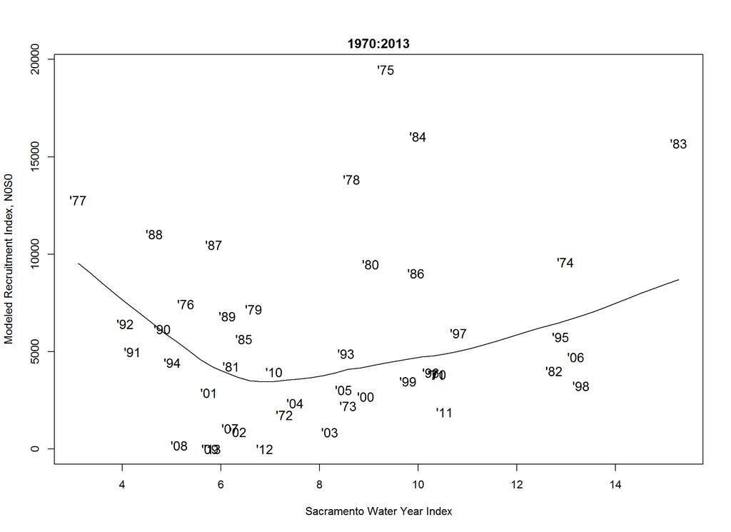

```r
# graphical settings
#par(mfrow=c(1,2))
par(mfrow=c(1,1))

# plot
wyPlots(nBY_use = myFit[["N0S0"]], years=names(myFit[["N0S0"]]),
        yLab="Modeled Recruitment Index, N0S0")
```

### nBYxCY (reversed)

Plot brood year composition for each catch year (uses nBYxCY data)

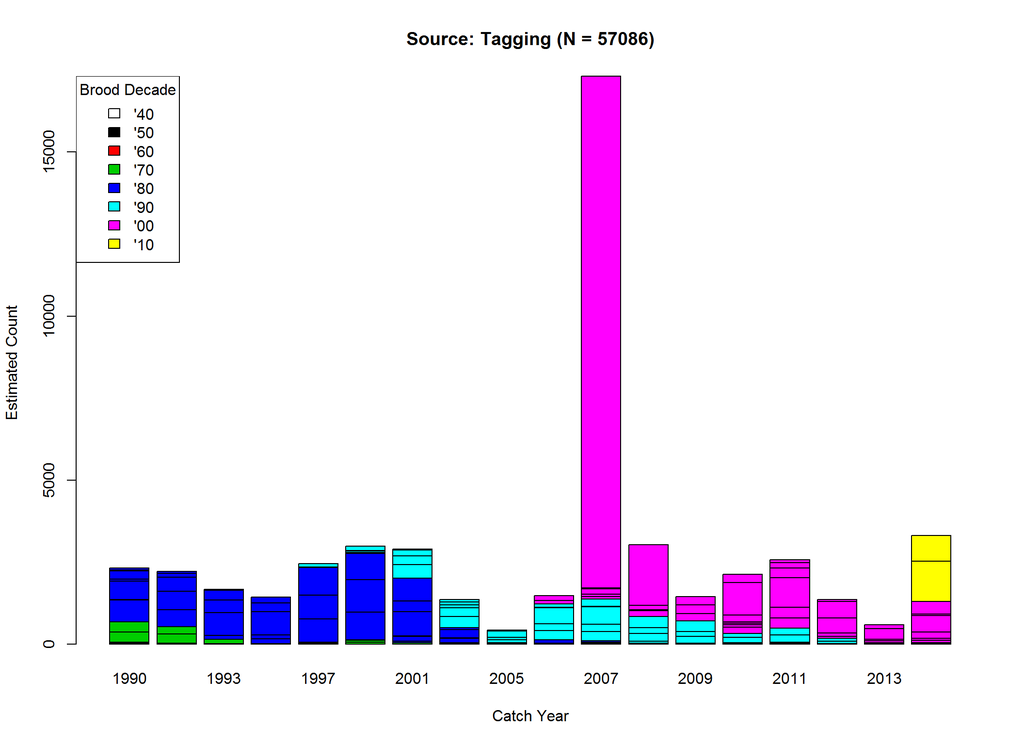

```r
# Plot brood year composition for each catch year:
barplot(nBYxCY, col=broodYrCol.decade[substr(row.names(nBYxCY),3,3)],
        xlab="Catch Year", ylab="Estimated Count",
        main=paste0("Source: ",selectSource," (N = ",sum(lenBinnedWide),")"))

# add legend
legend("topleft", unique(paste0("'",substr(row.names(nBYxCY),3,3),"0")),
       fill=broodYrCol.decade[unique(substr(row.names(nBYxCY),3,3))],
       title="Brood Decade")
```

### Age distributions (by catch year)

Plot age distributions by catch year

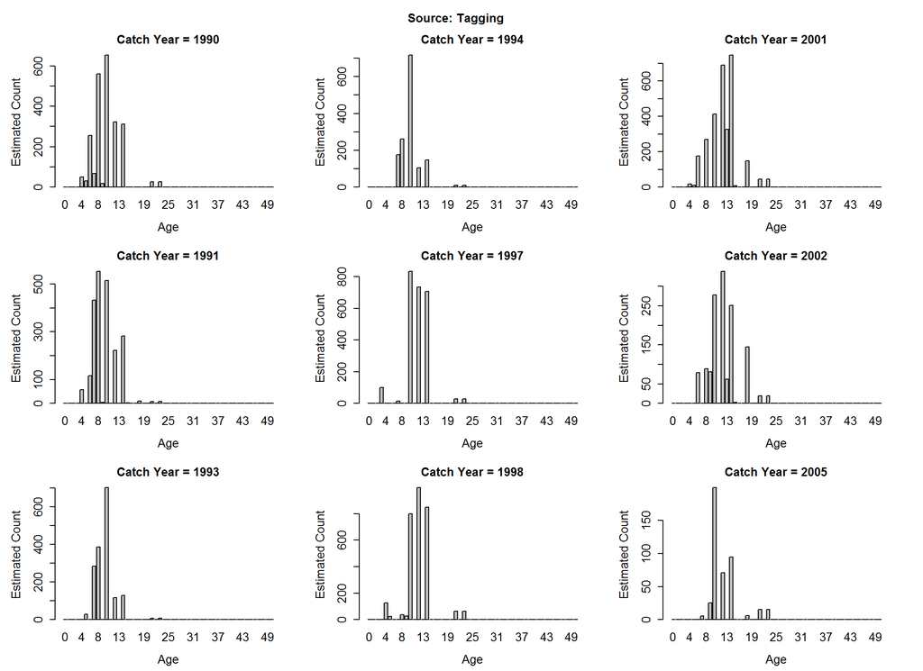

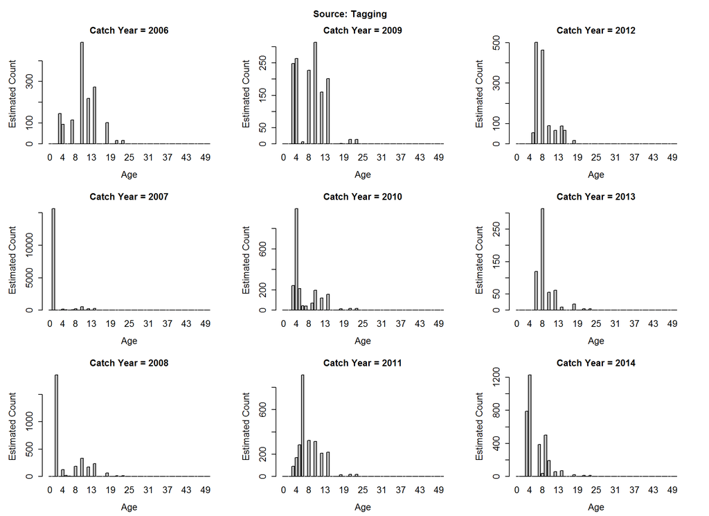

```r
## Plot age distributions by catch year:
plot_count <- 1
for(y.char in year.catch.char) {
  if(plot_count %% 9 == 1) {
    #if(usedevnew) dev.new(width=11, height=6, units="inch")

    # graphical settings
    par(mfcol=c(3,3), mar=c(4.5,5,3,2), oma=c(0,0,2,1),
    cex.axis=1.3, cex.lab=1.3, cex.main=1.3)
  }

  barplot(nAgeList[[y.char]], main=paste("Catch Year =",y.char),
          xlab="Age", ylab="Estimated Count")

  if(plot_count %% 9 == 1) {
    title(main=paste("Source:",selectSource), outer=TRUE, line=0, cex=1.3)
  }

  plot_count <- plot_count + 1
}
```

### Histogram (ages from ALK)

Plot histogram of ages from age-length key

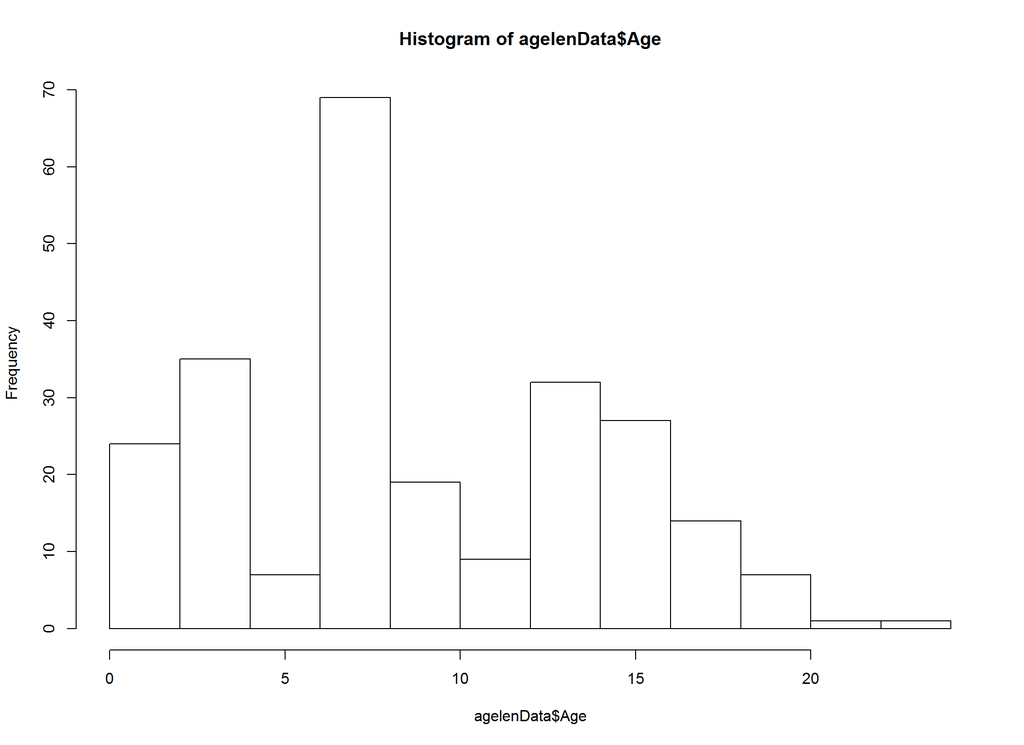

### nBYxAgeWide

Plot number-at-age from each brood year. Uses data from “nBYxAgeWide.”

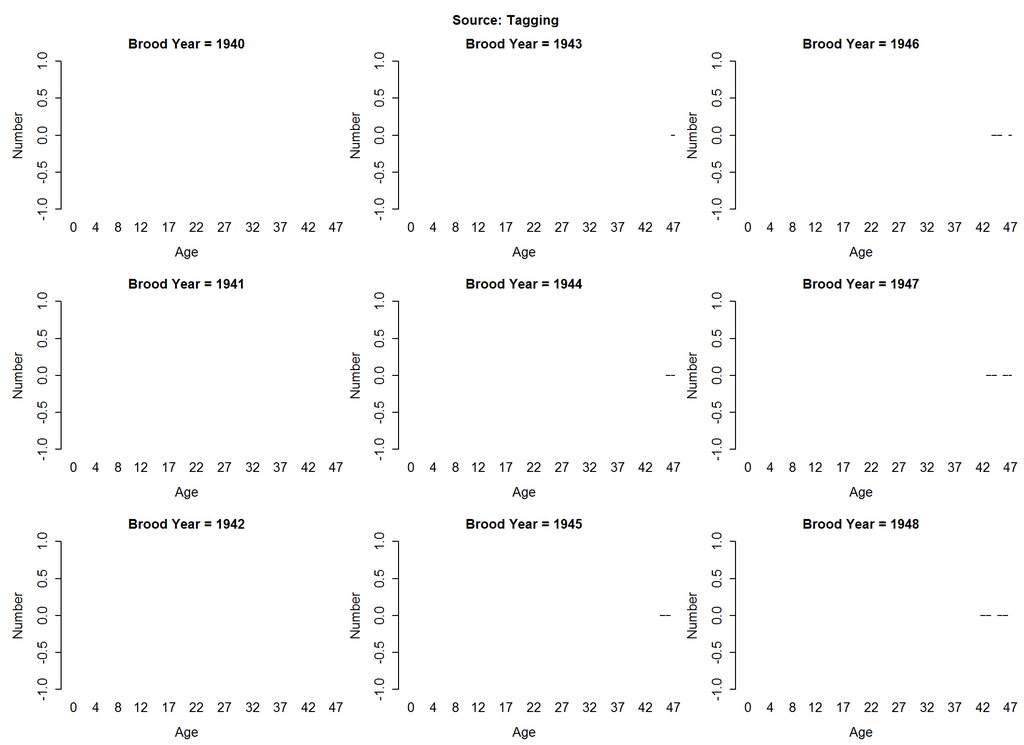

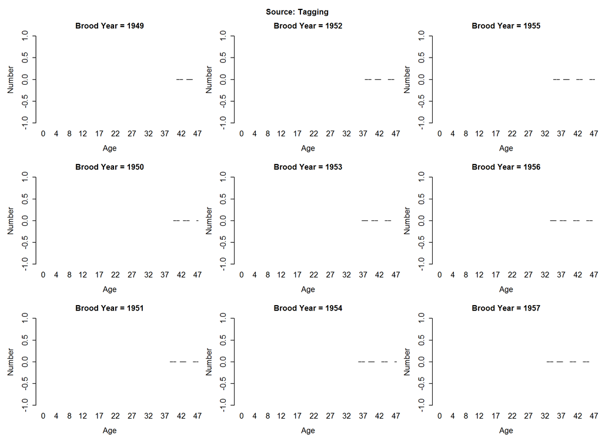

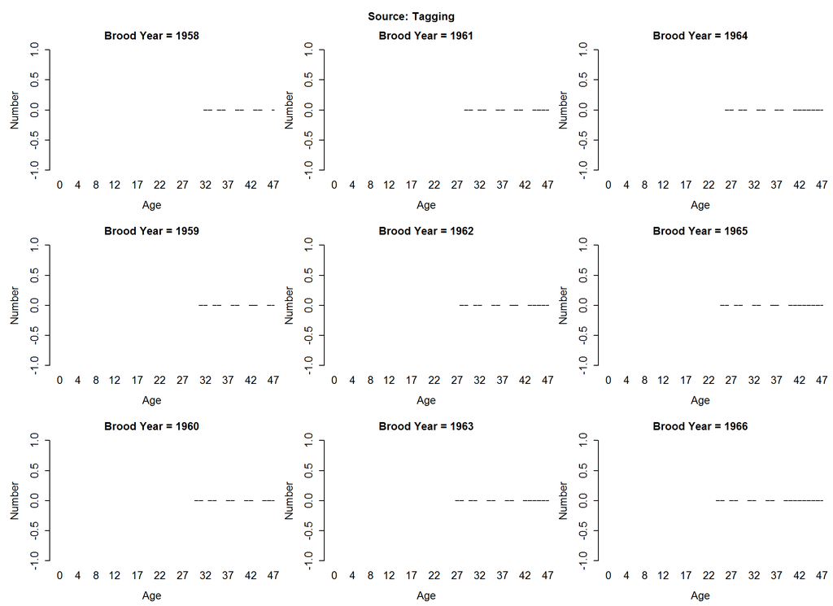

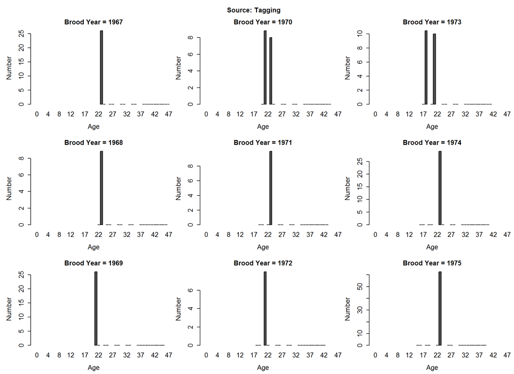

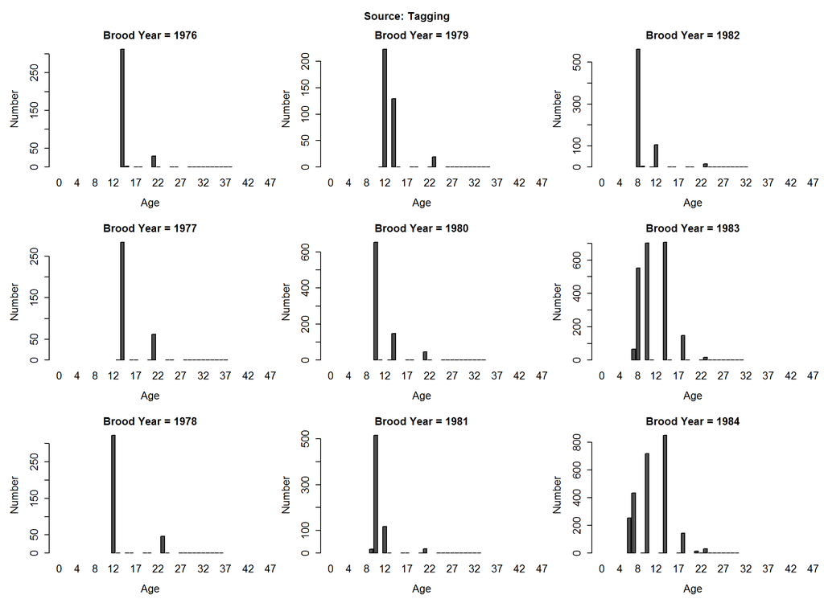

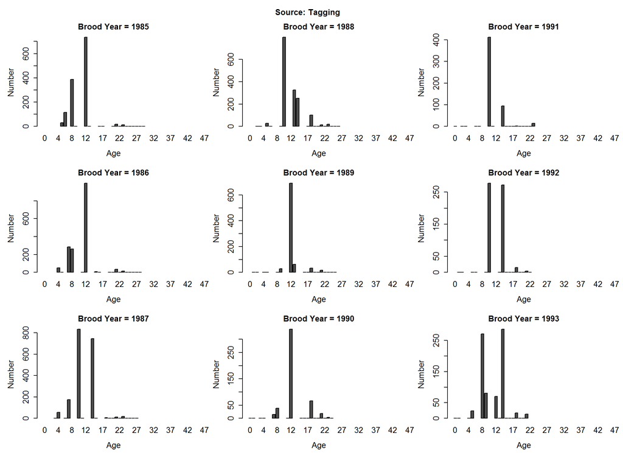

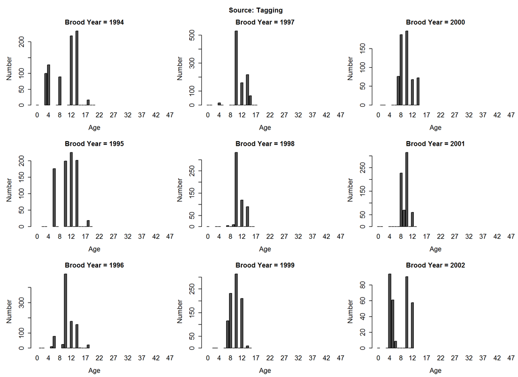

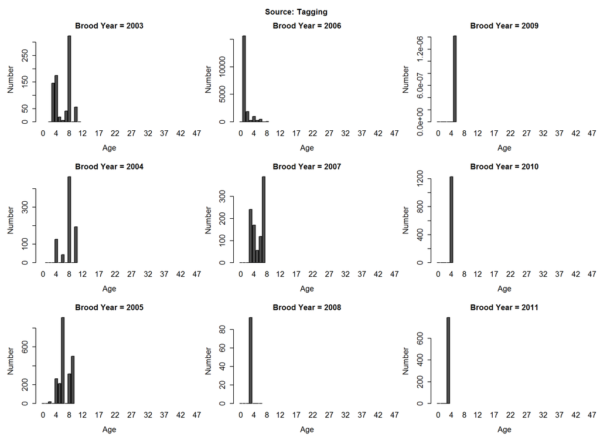

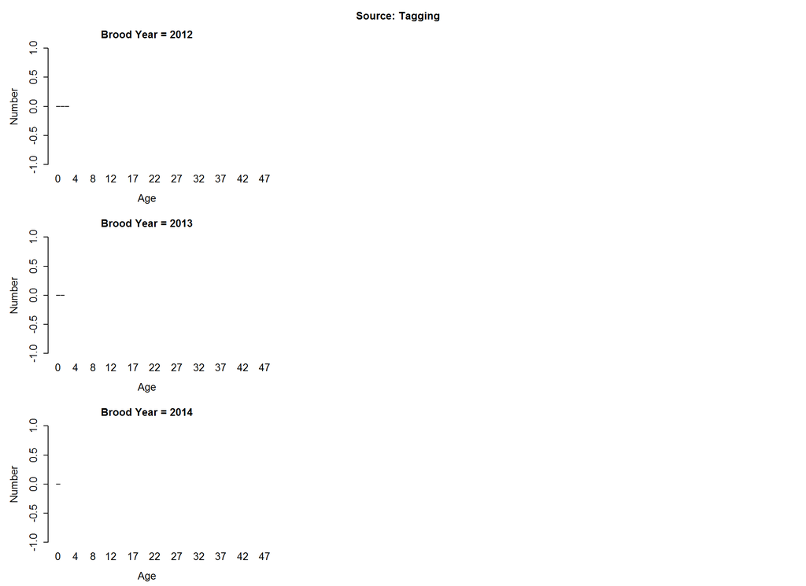

```r
# Plot number-at-age from each brood year:

plot_count <- 1
for(by.char in year.brood.char) {
  if(plot_count %% 9 == 1) {

    #if(usedevnew) dev.new(width=11, height=6, units="inch")

    # graphical settings
    par(mfcol=c(3,3), mar=c(4.5,5,3,2), oma=c(0,0,2,1),
    cex.axis=1.3, cex.lab=1.3, cex.main=1.3)

  }

  barplot(t(nBYxAgeWide[by.char, ]), main=paste("Brood Year =",by.char),
          xlab="Age", ylab="Number", xlim=c(0,50)) # ylim=c(0,50)

  if(plot_count %% 9 == 1) {
    title(main=paste("Source:",selectSource), outer=TRUE, line=0, cex=1.3)
  }

  plot_count <- plot_count + 1
}
```

### Scatter Num Caught v Num Assigned Age

Plot number of fish caught vs. number of fish assigned an age. Examine how many length-only fish were excluded due to holes in the age-length data.

```r
# Examine how many length-only fish were excluded due to holes in the age-length
# data. With the use of BayStudyOtterTrawlKey, there shouldn't be that many:

origNumCaught.by.CY <- with(taggingData, sapply(split(Count, Year), sum))
numAssignedAnAge.by.CY <- apply(nBYxCY, 2, sum)

# FALSE if names are identical
any(names(origNumCaught.by.CY) != names(numAssignedAnAge.by.CY))
```

```
[1] FALSE
```

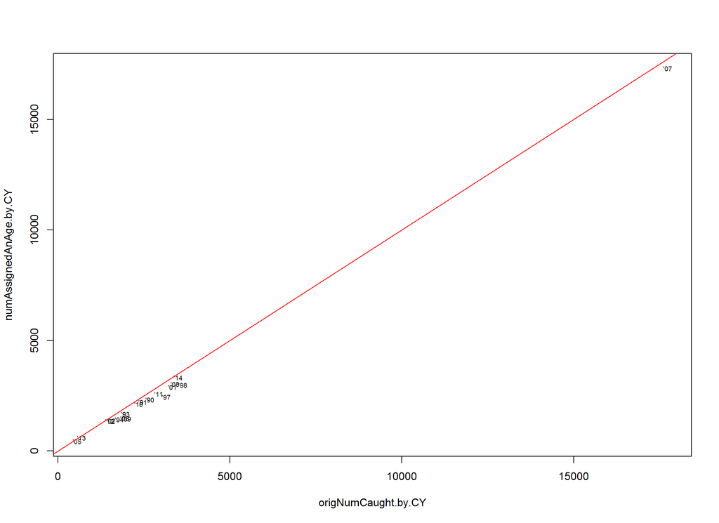

```r
#dev.new()

# I added cex = 0.6 so years on plot would be less obscured (J. DuBois,
# 01-Jul-2015)
plot(origNumCaught.by.CY, numAssignedAnAge.by.CY, pch=NA)
text(origNumCaught.by.CY, numAssignedAnAge.by.CY, cex = 0.6,
     paste0("'",substr(names(origNumCaught.by.CY),3,4)))

# adds straight line with slope = 1 and intercept = 0
abline(0, 1, col="red")
```

## Growth Models

In the file “WS_broodcomp_growthmodel.r,” LM “investigates different growth models for California White Sturgeon.” The four models presented are listed below, where VB means von Bertalanffy.

- VB.Normal (additive errors)
- VB.LogNormal (multiplicative errors)
- Gompertz.Normal (additive errors)
- Gompertz.LogNormal (multiplicative errors)

```r
summary(agelenData$ForkLength)
```

```
   Min. 1st Qu.  Median    Mean 3rd Qu.    Max.
  6.013  70.000  84.000  94.590 134.900 153.700
```

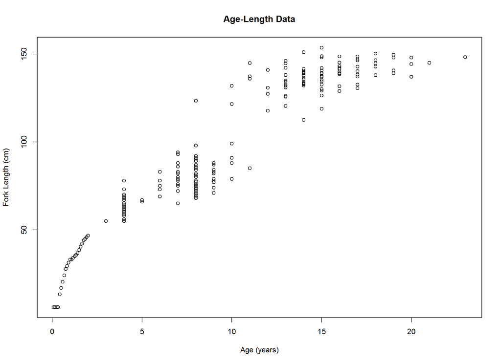

```r
# ForkLength vs. Age:
#dev.new(width=10, height=7, units="inch")
with(agelenData,
     plot(Age, ForkLength, xlab="Age (years)", ylab="Fork Length (cm)",
          main="Age-Length Data")
     )
```

Plot growth models (should be plotting - need to investigate…)

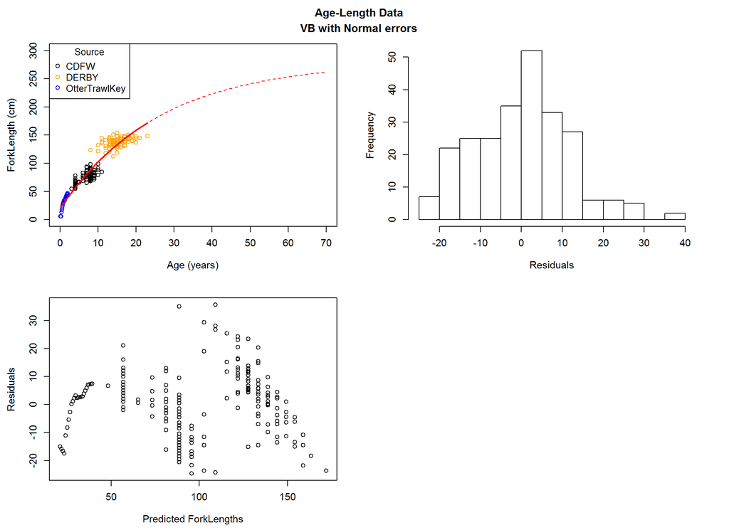

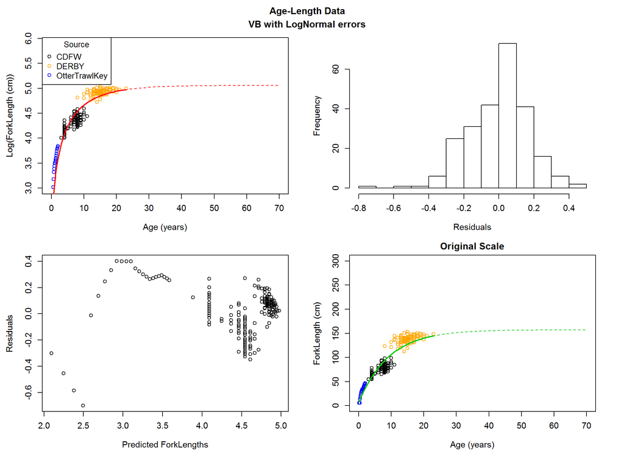

```r
## VBGM, Additive errors:
vb_additive <- fit.GM(growthModelType="VB.Normal", plotBool=TRUE,
                      newDev=FALSE)

## VBGM, Multiplicative errors:
vb_multi <- fit.GM(growthModelType="VB.LogNormal", plotBool=TRUE,
                   newDev=FALSE)
```

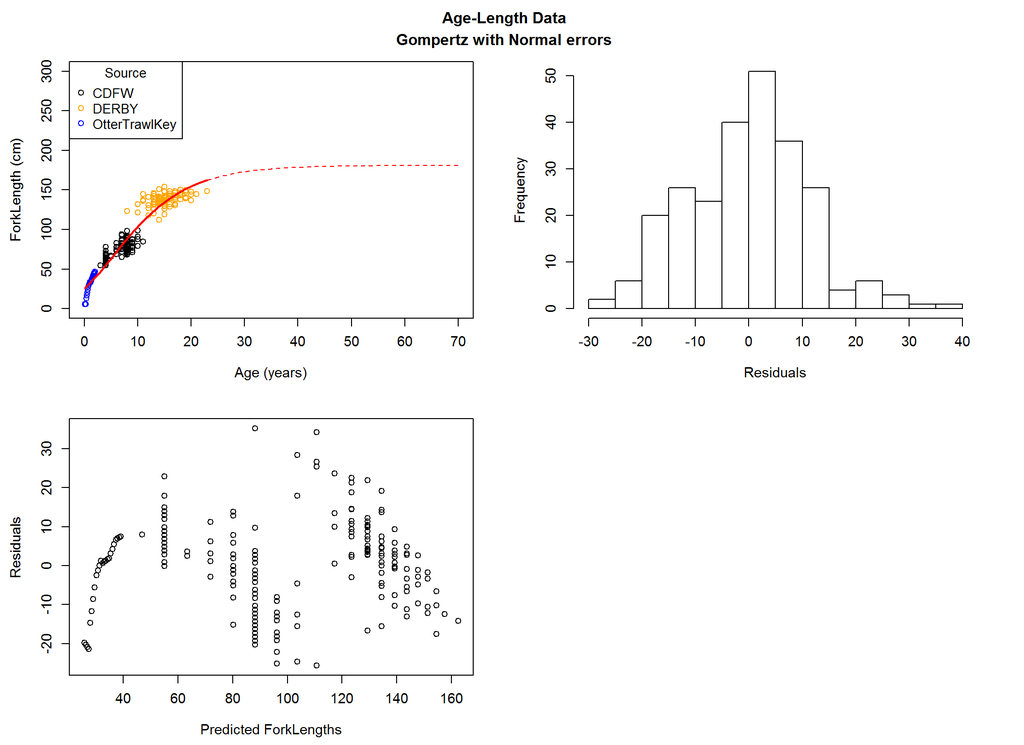

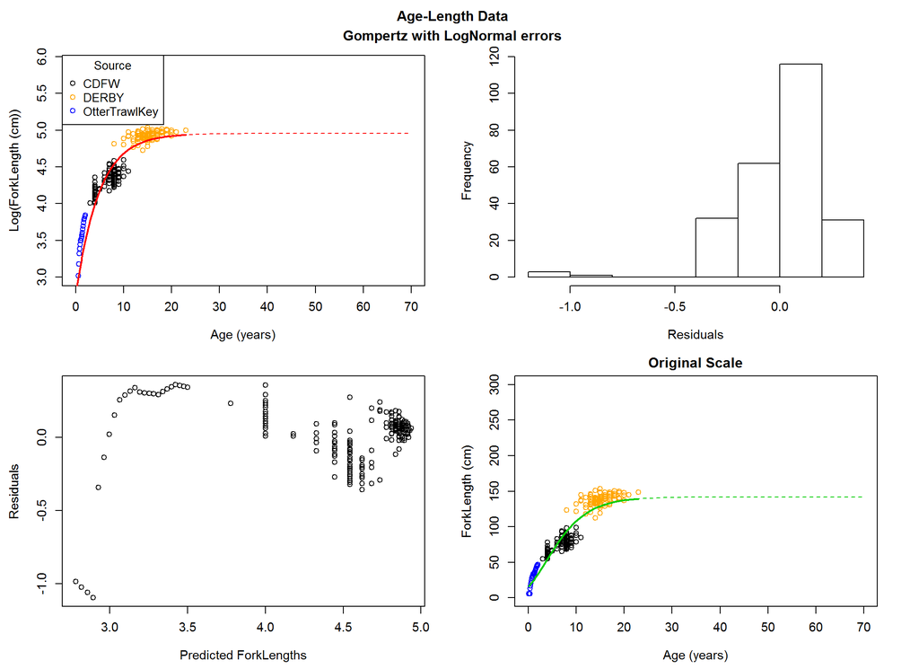

```r
## Gompertz, Additive errors:
Gomp_additive <- fit.GM(growthModelType="Gompertz.Normal", plotBool=TRUE,
                        newDev=FALSE)

## Gompertz, Multiplicative errors:
Gomp_multi <- fit.GM(growthModelType="Gompertz.LogNormal", plotBool=TRUE,
                     newDev=FALSE)
```

```r
# display summary output for each model
vb_additive
```

```
Nonlinear regression model
  model: ForkLength ~ 280 * (1 - exp(-K * (Age - t0)))
   data: agelenData
       K       t0
 0.03812 -1.96363
 residual sum-of-squares: 32488

Number of iterations to convergence: 4
Achieved convergence tolerance: 3.39e-07
```

```r
vb_multi
```

```
Nonlinear regression model
  model: ln_ForkLength ~ log(Linf * (1 - exp(-K * (Age - t0))))
   data: agelenData
    Linf        K       t0
157.2643   0.1085  -0.4051
 residual sum-of-squares: 7.328

Number of iterations to convergence: 6
Achieved convergence tolerance: 8.265e-06
```

```r
Gomp_additive
```

```
Nonlinear regression model
  model: ForkLength ~ Linf * exp(alpha * exp(beta * Age))
   data: agelenData
    Linf    alpha     beta
181.0257  -1.9689  -0.1261
 residual sum-of-squares: 31651

Number of iterations to convergence: 6
Achieved convergence tolerance: 3.224e-06
```

```r
Gomp_multi
```

```
Nonlinear regression model
  model: ln_ForkLength ~ log(Linf * exp(alpha * exp(beta * Age)))
   data: agelenData
   Linf   alpha    beta
141.841  -2.213  -0.210
 residual sum-of-squares: 11.06

Number of iterations to convergence: 8
Achieved convergence tolerance: 4.964e-06
```

## Custom Functions

LM’s custom functions require the following R packages (functions).

- pscl (function: zeroinfl)
- MASS (function: glm.nb)
- ALKr (function: kimura_chikuni)

Below are vectors used in various plot functions. The vectors mostly are used for colors in the plots.

```r
# Vectors for easier plotting:

# Plot colors for the length-only data catch years:
catchYrCol <- c("black","red","green3","blue","cyan","magenta","yellow","gray",
                "brown1","darkorange2","darkturquoise","deeppink1",
                "hotpink","khaki","lightgreen","lightslateblue","midnightblue",
                "mediumorchid","royalblue2",
                "peachpuff","skyblue2","thistle3","springgreen","yellow2",
                "steelblue4")

names(catchYrCol) <- as.character(1990:2014)

# Plot colors for brood years. Too many brood years, so color according to
# decade.
broodYrCol.decade <- c("black","red","green3","blue","cyan","magenta","yellow")

names(broodYrCol.decade) <- c("5","6","7","8","9","0","1")

# Plot colors for age-length data based on source.
sourceCol <- c("CDFW"="black", "DERBY"="orange", "OtterTrawlKey"="blue")
```

### growthCurveFcn

The `growthCurveFcn` function returns a length (given an age) based on either the von Bertalanffy algorithm or the Gompertz algorithm. The selection of the algorithm depends on the second parameter of the argument being passed to “paramObject.”

```r
growthCurveFcn <- function(paramObject, age) {
  # param can be an nls object or a vector.

  if(class(paramObject) == "nls") {
    paramVec <- coef(fit)
  } else {
    paramVec <- paramObject
  }

  if("K" %in% names(coef)) {  # von Bertalanffy
    Linf <- paramVec["Linf"]
    K <- paramVec["K"]
    t0 <- paramVec["t0"]

    return( Linf*(1-exp(-K*(age-t0))) )

  } else if("alpha" %in% names(coef)) { # Gompertz
    Linf <- paramVec["Linf"]
    alpha <- paramVec["alpha"]
    beta <- paramVec["beta"]

    return( Linf*exp(alpha*exp(beta*age)) )
  }
}
```

### fit.GM

The `fit.GM` function fits a growth model (GM) to age and length data from the age-length key. This function returns the model fit (for any one of four model types) and if desired will display 3-4 plots (scatter of residuals as a function of predicted fork lengths, length as a function of age, and a histogram of residuals).

```r
fit.GM <- function(growthModelType, plotBool=FALSE, newDev=TRUE) {
  # For debugging: growthModelType <- "VB.Normal"

  ## Used globally: agelenData

  if(growthModelType == "VB.Normal") {
    ## VBGM, Additive errors:
    gmFormula <- ForkLength ~ 280*(1-exp(-K*(Age-t0)))
    init <- list(K = 0.15, t0 = 0)  #list(Linf = 225, K = 0.15, t0 = 0)

  } else if(growthModelType == "VB.LogNormal") {
    ## VBGM, Multiplicative errors:
    gmFormula <- ln_ForkLength ~ log( Linf*(1-exp(-K*(Age-t0))) )
    init <- list(Linf = 225, K = 0.15, t0 = -1)

  } else if(growthModelType == "Gompertz.Normal") {
    ## Gompertz, Additive errors:
    gmFormula <- ForkLength ~ Linf*exp(alpha*exp(beta*Age))
    init <- list(Linf = 225, alpha = -1.5, beta = -0.15)

  } else if(growthModelType == "Gompertz.LogNormal") {
    ## Gompertz, Multiplicative errors:
    gmFormula <- ln_ForkLength ~ log( Linf*exp(alpha*exp(beta*Age)) )
    init <- list(Linf = 225, alpha = -1.5, beta = -0.15)

  }

  modelName <- strsplit(growthModelType, split=".", fixed=TRUE)[[1]][1]
  modelError <- strsplit(growthModelType, split=".", fixed=TRUE)[[1]][2]

  fit <- nls(gmFormula, data=agelenData, start=init)
  fit[["growthModelType"]] <- growthModelType
  fit[["modelName"]] <- modelName
  fit[["modelError"]] <- modelError

  ## Create plots:
  if(plotBool) {
    pred <- predict(fit)
    res <- resid(fit)

    if(newDev) dev.new(width=11, height=9, units="inch")
    par(mfrow=c(2,2),mar=c(4.5,4.5,2,2),oma=c(0,0,2,1),cex.axis=1.1,
          cex.lab=1.1)

    xLim <- c(0,70)
    yLim_N <- c(0,300)
    yLim_LN <- c(3,5.9)
    if(modelError=="Normal") {
      plot(agelenData$Age, agelenData$ForkLength, xlab="Age (years)",
            ylab="ForkLength (cm)", ylim=yLim_N, #max(agelenData$ForkLength)),
            col=sourceCol[agelenData$Source], xlim=xLim)
    } else if(modelError=="LogNormal") {
      plot(agelenData$Age, agelenData$ln_ForkLength, xlab="Age (years)",
            ylab="Log(ForkLength (cm))", ylim=yLim_LN, xlim=xLim,
            col=sourceCol[agelenData$Source])
    }
    legend("topleft", names(sourceCol), col=sourceCol, pch=1, title="Source")

    lines(agelenData$Age, pred, col="red", lwd=2)
    lines(0:70, predict(fit,data.frame("Age"=0:70)), col="red", lwd=1, lty=2)
    hist(res, main="", xlab="Residuals")
    plot(pred, res, xlab="Predicted ForkLengths", ylab="Residuals")

    if(modelError=="LogNormal") {
      plot(agelenData$Age, agelenData$ForkLength, xlab="Age (years)",
            ylab="ForkLength (cm)", ylim=yLim_N, #max(agelenData$ForkLength)),
            col=sourceCol[agelenData$Source], xlim=xLim,
            main="Original Scale")
      lines(agelenData$Age, exp(pred), col="green3", lwd=2)
      lines(0:70, exp(predict(fit,data.frame("Age"=0:70))), col="green3",
            lwd=1, lty=2)
    }

    title(main="Age-Length Data", outer=TRUE, line=0.5)
    title(main=paste(modelName,"with",modelError,"errors"), outer=TRUE,
          line=-0.9)
#    title(main="Age-Length Data", outer=TRUE, line=-2)
#    title(main=paste(modelName,"with",modelError,"errors"), outer=TRUE,
#          line=-3.5)
  }

  return(fit)
}
```

### InvALK.fcn

The `InvALK.fcn` function (per LM) generates p_{L|A} using length and age classes specified in interval_table. This function returns the probabilities (either normal or lognormal) of length given age (?? I think) based on the results of the model fit (passed to the “growthModelFit” function parameter).

```r
InvALK.fcn <- function(growthModelFit, len, age, interval_table) {
  # For debugging:
  # growthModelFit <- myFit; len <- lengthVec[1]; age <- ageVec;
  # interval_table <- alk_lookup

  ## age can be a vector, but len should be a scalar.

  modelName <- growthModelFit[["modelName"]]
  modelError <- growthModelFit[["modelError"]]

  MN <- predict(growthModelFit, data.frame("Age"=as.numeric(age)))
  SD <- summary(growthModelFit)[["sigma"]]

  # there should only be one match!
  index <- with(interval_table, which(lower <= len & len < upper))
  if(length(index) > 1) {
    cat("Error in the function InvALK()\n")
    return(NULL)
  }

  low <- interval_table[index,"lower"]
  upp <- interval_table[index,"upper"]

  smallestLength <- interval_table[1,"lower"]
  largestLength <- interval_table[nrow(interval_table),"upper"]

  if(modelError == "Normal") {
    scaleBy <- pnorm(largestLength, mean=MN, sd=SD) -
                    pnorm(smallestLength, mean=MN, sd=SD)
    probs <- (pnorm(upp, mean=MN, sd=SD) - pnorm(low, mean=MN, sd=SD))/scaleBy

  } else if(modelError == "LogNormal") {
    MN_adj <- MN - SD^2/2

    scaleBy <- plnorm(largestLength, meanlog=MN_adj, sd=SD) -
                    plnorm(smallestLength, meanlog=MN_adj, sd=SD)
    probs <- (plnorm(upp, meanlog=MN_adj, sd=SD) -
                plnorm(low, mean=MN_adj, sd=SD))/scaleBy

#    dev.new()
#    plot(1:300, pnorm(log(1:300),MN,SD))
#    lines(1:300, plnorm(1:300, MN, SD), lwd=2, col="green3")
#    tmp <- rlnorm(2000, MN_adj, SD)
#    abline(v=median(tmp), col="red", lwd=2)
#    abline(v=mean(tmp), col="blue", lwd=2)
  } else {
    return(NULL)
  }

  return(probs)
}
```

### kimura_chikuni_custom

The `kimura_chikuni_custom` function (per LM) calculates an iterated ALK using the Kimura-Chikuni algorithm. LM adapted this function from the `ALKr` package.

Below is from R Documentation about the `kimura_chikuni` function in the `ALKr` package.

- x = A *i* times *j* matrix with *i* lines and *j* columns, where *x[i, j]* is the count of individuals of length *i* and age *j*
- fi2 = A vector of length *i* where *fi[i]* is the number of fish in the length-class *i* on a population with unknown age information

```r
kimura_chikuni_custom <- function(x, fi2, threshold = 1e-04, maxiter = 20000,
                              age_classes = colnames(x),
                              length_classes = rownames(x), name = "",
                              description = "")
{
    invAlk <- x # calc_invALK(calc_ALK(x), fi1) # wants l|a, dimensions L X A
    pj2 <- rep(1/ncol(x), ncol(x))
    criterion <- 1
    iter <- 0

    while (criterion > threshold & iter < maxiter) {
        pj2.old <- pj2
        alk <- t(t(invAlk) * pj2)/rowSums(t(t(invAlk) * pj2))

        ############################
        ## Can have problems with dividing by 0 if no growth model is
        ## used and there are holes in invALK.
        #cat("filling in nan's\n")
        alk[is.nan(alk)] <- 0
        ############################

        nij <- fi2 * alk
        pj2 <- colSums(nij)/sum(nij)
        criterion <- sum(abs(pj2 - pj2.old))
        iter <- iter + 1
    }
    new("ALKr", alk = calc_ALK(nij), N = nij, method = "Kimura & Chikuni",
        parameters = list(ConvergenceThreshold = threshold, Iterations = iter,
            Converged = iter < maxiter), name = name, description = description)
}
```

### ageAssignResults

The `ageAssignResults` function assigns ages given length data and an age-length key. Length data (the argument supplied to function parameter “lenDataSource”) can be tagging data, card data, or a combination of both. The age-length key (the argument supplied to function parameter “alkType”) can be either raw or iterated. The growth model (the argument supplied to function parameter “growthModelType”) can be any one of the four as outlined in the `fit.GM` function or empty (default).

Function parameters “lengthBinVec” and “ageBinVec” both require vectors in the form of “c(min, practicalMax, absoluteMax, stepSize),” values that are further explained below.

**Function Parameters Explained**  
A length frequency summary (per bin) is created for the fish lengths supplied in “lenDataSource.” Fish lengths are binned according to the values supplied in “lengthBinVec.” The bin width is defined by the “stepSize” value. Similarly, “ageBinVec” is used to bin ages. In LM’s example, she used 1 for the bin width (value in “stepSize”).

The arguments passed to function parameters “alkType” and “growthModelType” can affect the output of this function. “alkType” can be either ‘Raw’ or ‘Iterated.’ “growthModelType” can be any one of the four model types or nothing (blank, the default).

- **alkType: Raw**  
  Simply is the length frequency multiplied by the age-length key. A growth model — even if supplied — is not used.
- **alkType: Iterated**  
  Here we can supply a growth model or run without one
  - With growth model  
    An inverse age-length key is constructed from the model fit using function `InvALK.fcn`
  - Without growth model  
    An inverse age-length key is constructed from the age-length data directly
  - Use the inverse ALK to construct year-specific iterated ALKs (per LM notes in function). This step employs the function `kimura_chikuni_custom`, which is run for each catch year.

From the output of above (see “broodList” in body of function), many variables are derived, and these variables comprise the list that is the output of this function (see “returnList” in body of function).

WHAT IS AN INVERSE AGE-LENGTH KEY?

```r
ageAssignResults <- function(lenDataSource, lengthBinVec, ageBinVec, alkType,
                             growthModelType="") {
  ## Options for inputs:
  ##   lenDataSource: "Tagging", "Card", or "Both"
  ##   alkType: "Raw" or "Iterated"
  ##   growthModelType: "VB.Normal", "VB.LogNormal", "Gompertz.Normal",
  ##                    "Gompertz.LogNormal", or ""
  ##
  ## lengthBinVec and ageBinVec have the structure:
  ##              c(min, practicalMax, absoluteMax, stepSize)
  ##
  ## Examples:
  ##   lengthBinVec = c(20,250,300,5)
  ##   ageBinVec = c(0,40,70,1)
  ##

  # For debugging:
#  lenDataSource <- "Tagging"; lengthBinVec=c(20,160,300,5);
#  ageBinVec <- c(0,40,70,1)

#  alkType <- "Iterated"; growthModelType <- ""


  ## Validate (some) input:
  if(!lenDataSource %in% c("Tagging","Card","Both")) {
    cat("lenDataSource must be 'Tagging', 'Card', or 'Both'\n")
    return(NULL)
  } else if(!alkType %in% c("Raw","Iterated")) {
    cat("alkType must be 'Raw' or 'Iterated'\n")
    return(NULL)
  }


  validGM <- c("VB.Normal","VB.LogNormal","Gompertz.Normal",
               "Gompertz.LogNormal","")
  if(alkType=="Iterated" & !growthModelType %in% validGM)  {
    cat("Invalid growthModelType. See the function ageAssignResults().\n")
    return(NULL)
  }


  # Use the data frames agelenData cardData, taggingData, and bothData globally.
  # Define lenUse based on lenDataSource.
  agelenUse <- agelenData

  if(lenDataSource == "Tagging") {
    lenUse <- taggingData
  } else if(lenDataSource == "Card") {
    lenUse <- cardData
  } else if(lenDataSource == "Both") {
    lenUse <- bothData
  }


  ## Define length and age classes:
  lengthMin <- lengthBinVec[1]
  # left end of the last bin
  lengthMax <- lengthBinVec[2]
  # right end of the last bin; defines the "plus" length group
  lengthPlus <- lengthBinVec[3]
  lengthBinWidth <- lengthBinVec[4]

  ageMin <- ageBinVec[1]
  # left end of the last bin
  ageMax <- ageBinVec[2]
  # right end of the last bin; defines the "plus" age group
  agePlus <- ageBinVec[3]
  ageBinWidth <- ageBinVec[4]

  lengthBreaks <- c(seq(lengthMin, lengthMax, lengthBinWidth), lengthPlus)
  nLength <- length(lengthBreaks) - 1
  lengthVec <- (lengthBreaks[1:nLength] + tail(lengthBreaks,-1))/2
  lengthClass <- cut(lengthVec, breaks=lengthBreaks, right=FALSE)

  ageBreaks <- c(seq(ageMin, ageMax, ageBinWidth), agePlus)
  nAge <- length(ageBreaks) - 1
  ageVec <- ageBreaks[1:nAge]  # (ageBreaks[1:nAge] + tail(ageBreaks,-1))/2
  ageClass <- cut(ageVec, breaks=ageBreaks, right=FALSE)


  ## Check if any observed ages or lengths are being excluded:
  excludingLengths_1 <- with(lenUse, any(ForkLength < lengthMin) ||
                                            any(ForkLength > lengthPlus) )
  excludingLengths_2 <- with(agelenUse, any(ForkLength < lengthMin) ||
                                            any(ForkLength > lengthPlus) )
  excludingAges <- with(agelenUse, any(Age < ageMin) || any(Age > agePlus) )

  if(excludingLengths_1) {
    warning("Choice of lengthBinVec is excluding length-only fish")
  }

  if(excludingLengths_2) {
    warning("Choice of lengthBinVec is excluding age-length fish")
  }

  if(excludingAges) {
    warning("Choice of ageBinVec is excluding age-length fish")
  }



  ## Define the length-only catch years and brood years:
  # Catch years
  year.catch <- sort(unique(lenUse$Year))
  year.catch.char <- as.character(year.catch)
  nYearCatch <- length(year.catch)

  # Brood years:
  year.brood <- sort(unique(c(sapply(year.catch, function(x) x - ageVec))))
  year.brood.char <- as.character(year.brood)
  nYearBrood <- length(year.brood)



  ## Bin agelenUse and lenUse according to length and age classes:
  agelenUse$ForkLength <- floor(agelenUse$ForkLength)
  agelenUse$lengthClass <- cut(agelenUse$ForkLength, breaks=lengthBreaks,
                               right=FALSE)
  agelenUse$ageClass <- cut(agelenUse$Age, breaks=ageBreaks, right=FALSE)

  agelenBinned <- with(agelenUse, table(lengthClass, ageClass))


  ## Create two versions of lenBinned, one each in 'long' and 'wide' format:
  lenUse$lengthClass <- cut(lenUse$ForkLength, breaks=lengthBreaks, right=FALSE)

  # Long format: data.frame with columns = lengthClass, Year, Count
  lenBinnedLong <- expand.grid("lengthClass"=lengthClass, "Year"=year.catch)
  row.names(lenBinnedLong) <- with(lenBinnedLong,
                                   paste(Year, lengthClass, sep="."))
  lenBinnedLong[ ,"Count"] <- 0

  tmp <- with(lenUse, sapply(split(Count, list(Year,lengthClass),
                                   drop=TRUE), sum))
  lenBinnedLong[names(tmp),"Count"] <- tmp

  # Wide format: matrix with rows = lengthClass and columns = catch year
  lenBinnedWide <- matrix(NA, nrow=nLength, ncol=nYearCatch,
                             dimnames=list(lengthClass,year.catch.char))
  for(y.char in colnames(lenBinnedWide)) {
    tmp <- subset(lenBinnedLong, Year==as.numeric(y.char))
    tmpRowNames <- substring(row.names(tmp), first=6)
    lenBinnedWide[tmpRowNames,y.char] <- tmp$Count
  }



  ## Construct ALK and apply it to get number-at-age and brood years.
  nAgeList <- vector(mode="list", length=nYearCatch)
  names(nAgeList) <- year.catch.char
  broodList <- nAgeList

  if(alkType == "Raw") {

    # Use agelenBinned to directly construct an ALK, p_{A|L}:
    alk <- matrix(0, nrow=nLength, ncol=nAge,
                  dimnames=list(lengthClass,ageClass))
    for(L.char in rownames(agelenBinned)) {
      for(A.char in colnames(agelenBinned)) {

        # lengthClass and ageClass should be factors, because cut() was
        # used, in which case there won't be a problem here.
        # Just to be sure, double check that A.char is represented in alk:
        if(A.char %in% colnames(alk)) {
          alk[L.char, A.char] <- agelenBinned[L.char , A.char]
        }

      }
    }
    for(i in 1:nrow(alk)) {
      alk[i, ] <- alk[i, ] / sum(alk[i, ])  # Divide by the row total
    }
    alk[is.nan(alk)] <- 0                   # Replace NaNs with 0

    # Save the ALK:
    alkList <- list(alk)

    # Apply the ALK to each catch year:
    for(y in year.catch) {
      nLY <- lenBinnedWide[ ,as.character(y)]
      nAY <- c(t(alk) %*% nLY)   # need [age x length]
      names(nAY) <- ageVec
      nAgeList[[as.character(y)]] <- nAY

      tmp <- nAY
      names(tmp) <- (y - as.numeric(names(nAY)))
      broodList[[as.character(y)]] <- tmp
    }

  } else if(alkType == "Iterated") {

    if(growthModelType != "") {
      # Fit growthmodel:
      myFit <- fit.GM(growthModelType, plotBool=FALSE)

      # This is used to integrate over length-at-age in invalk().
      alk_lookup <- data.frame("lower"=lengthBreaks[1:nLength],
                               "upper"=tail(lengthBreaks,-1))

      # Construct inverse ALK:
      invalk <- matrix(NA, nrow=nLength, ncol=nAge,
                       dimnames=list(lengthClass,ageClass))
      for(i in seq(nrow(invalk))) {
        invalk[i, ] <- InvALK.fcn(myFit, lengthVec[i], ageVec, alk_lookup)
      }

    } else if(growthModelType == "") {
      # Construct inverse ALK from the age-length data directly. There will be
      # holes!
      invalk <- matrix(0, nrow=nLength, ncol=nAge,
                       dimnames=list(lengthClass,ageClass))
      for(L.char in rownames(agelenBinned)) {
        for(A.char in colnames(agelenBinned)) {

          # Double check:
          if(A.char %in% colnames(invalk)) {
            invalk[L.char, A.char] <- agelenBinned[L.char , A.char]
          }

        }
      }
      for(i in 1:ncol(invalk)) {
        # Divide by the column total
        invalk[ ,i] <- invalk[ ,i] / sum(invalk[ ,i])
      }
      # Replace NaNs with 0
      invalk[is.nan(invalk)] <- 0

    }

    # Use inverse ALK to construct year-specific iterated ALKs:
    alkList <- nAgeList

    for(y in year.catch) {
      nLY <- lenBinnedWide[ ,as.character(y)]
      ialk <- kimura_chikuni_custom(x=invalk, fi2=nLY)

      # Save the iterated ALK:
      alkList[[as.character(y)]] <- ialk

      nAY <- c(t(ialk@alk) %*% nLY)   # need [age x length]
      names(nAY) <- ageVec
      nAgeList[[as.character(y)]] <- nAY
      # kc$N = pAgivenL_y with each column multiplied by nLY.
      # apply(kc@N,2,sum) is another way to get nAY.

      tmp <- nAY
      names(tmp) <- (y - as.numeric(names(nAY)))
      broodList[[as.character(y)]] <- tmp
    }

  }


  ## Brood year counts by Brood Year and Catch Year (matrix):
  fullyrbrood <- unlist(lapply(broodList, function(x) as.numeric(names(x))))
  yrbrood <- sort(unique(fullyrbrood)) # should be identical to year.brood.char
  nBYxCY <- matrix(0, nrow=length(yrbrood), ncol=nYearCatch,
                        dimnames=list(yrbrood,year.catch.char))
  for(y.char in colnames(nBYxCY)) {
    nBYxCY[names(broodList[[y.char]]),y.char] <- broodList[[y.char]]
  }

  ## Brood year counts by Brood Year only (vector):
  nBY <- apply(nBYxCY, 1, sum)


######################
######################
## This code will break if age classes aren't integers 0, 1, 2, ...

  ## Brood year counts by Brood Year and Age (matrix):
  cyear.byear <- unlist(broodList)
  split_by_by <- split(cyear.byear, substr(names(cyear.byear),6,9))
  split_by_by <- lapply(split_by_by, function(x) {
                    names(x) <- substr(names(x),1,4)
                    return(x) })
  for(i in names(split_by_by)) {
    tmp <- split_by_by[[i]]
    names(tmp) <- as.numeric(names(tmp)) - as.numeric(i)
    split_by_by[[i]] <- tmp
  }

  nBYxAgeWide <- matrix(NA, nrow=nYearBrood, ncol=length(ageVec),
                        dimnames=list(year.brood.char,ageVec))
  for(by.char in rownames(nBYxAgeWide)) {
    ## The broodYear-age combinations that are impossible, given the
    ## range of catch years, are left as NAs.
    ## The vector names(split_by_by[[by.char]]) ensures that only
    ## physically possible ages get filled in.

    nBYxAgeWide[by.char, names(split_by_by[[by.char]])] <-
      split_by_by[[by.char]]
  }

  ## A version of nBYxAgeWide that is long instead of wide:
  nBYxAgeLong <- expand.grid("Age"=as.numeric(colnames(nBYxAgeWide)),
                             "BroodYear"=as.numeric(rownames(nBYxAgeWide)))
  for(i in seq(nrow(nBYxAgeLong))) {
    age.char <- as.character(nBYxAgeLong[i,"Age"])
    broodyr.char <- as.character(nBYxAgeLong[i,"BroodYear"])
    nBYxAgeLong[i,"Number"] <- nBYxAgeWide[broodyr.char,age.char]
  }

######################
######################


  ## Return lots of things.
  returnList <- list("lenDataSource"=lenDataSource,
                    "lengthBinVec"=lengthBinVec,
                    "ageBinVec"=ageBinVec,
                    "alkType"=alkType,
                    "growthModelType"=growthModelType,
                    "lengthClass"=lengthClass,
                    "ageClass"=ageClass,
                    "year.catch"=year.catch,
                    "year.brood"=year.brood,
                    "agelenBinned"=agelenBinned,
                    "lenBinnedLong"=lenBinnedLong,
                    "lenBinnedWide"=lenBinnedWide,
                    "alkList"=alkList,
                    "nAgeList"=nAgeList,
                    "broodList"=broodList,
                    "nBYxCY"=nBYxCY,
                    "nBY"=nBY,
                    "nBYxAgeWide"=nBYxAgeWide,
                    "nBYxAgeLong"=nBYxAgeLong)

  if(alkType == "Iterated" & growthModelType != "") {
    returnList[["gmFit"]] <- myFit
    returnList[["alk_lookup"]] <- alk_lookup
    returnList[["invalk"]] <- invalk
  }

  if(alkType == "Iterated" & growthModelType == "") {
    returnList[["invalk"]] <- invalk
  }

  return(returnList)
}
```

### fitExpModel

The `fitExpModel` function (per LM) fits an exponential model to the number-at-age by brood-year. The results from the function `ageAssignResults` are passed to the function parameter “resultObject.” Function parameter “bySubsetVec” (per LM) is a vector containing the brood years that should be used in the model. Function parameter “formulaOpt” (per LM) accepts an integer (1-6) indicating what type of model should be used (the details of this parameter will be described in full below). Function option to print is set (defaults) to TRUE (i.e., yes display plot).

```r
fitExpModel <- function(resultObject, bySubsetVec, formulaOpt, plotBool=TRUE,
                          usedevnew=TRUE) {
  # For debugging: resultObject <- myResults; bySubsetVec <- c(1980:2013);

  #                resultObject <- myResults; bySubsetVec <- c(1980:2013);

  ## resultObject is a list returned by the ageAssignResults() function.
  ## bySubsetVec is a vector containing the brood years that should be
  ##   used in the model.
  ## formulaOpt is an integer indicating what type of model should be used,
  ##   see below.

  ## formulaOpt:
  ##  1 = NB; separate N0S0 for each brood year; one lambda.
  ##  2 = NB; one N0S0 for all brood years; one lambda.
  ##  3 = ZINB; separate N0S0 for each brood year; one lambda;
  ##            separate pi for each brood year.
  ##  4 = ZINB; separate N0S0 for each brood year; one lambda;
  ##            one pi for all brood years.
  ##  5 = Poisson; separate N0S0 for each brood year; one lambda.
  ##  6 = ZIP; separate N0S0 for each brood year, one lambda; one pi.


  # Round the number-at-age to the nearest integer and create
  # a column with BroodYear as a factor:
  nBYxAgeLong <- resultObject[["nBYxAgeLong"]]
  nBYxAgeLong$Num.int <- round(nBYxAgeLong$Number)
  nBYxAgeLong$BY.factor <- as.factor(nBYxAgeLong$BroodYear)

  nBYxAgeLong_sub <- subset(nBYxAgeLong, BroodYear %in% bySubsetVec)


  # Define the model formula and fit it:
  if(formulaOpt == 1) {

    ## NB.
    ## Num.int_{BY} = N0S0_{BY} * exp(-Age*t)
    use.fmla <- as.formula(Num.int ~ BY.factor + Age)
    use.fit <- glm.nb(as.formula(use.fmla), data=nBYxAgeLong_sub,
                        na.action = na.omit)
    #control=glm.control(maxit=200,trace = 3))

  } else if(formulaOpt == 2) {

    ## NB.
    ## Num.int_{BY} = N0S0 * exp(-Age*t)
    use.fmla <- as.formula(Num.int ~ Age)
    use.fit <- glm.nb(as.formula(use.fmla), data=nBYxAgeLong_sub,
                        na.action = na.omit)

  } else if(formulaOpt == 3) {

    ## Zero-inflated NB.
    ## Num.int_{BY} = N0S0_{BY} * exp(-Age*t)
    ## Separate pi for each brood year.
    use.fmla <- as.formula(Num.int ~ BY.factor + Age | BY.factor)
    use.fit <- zeroinfl(use.fmla, dist="negbin", data=nBYxAgeLong_sub,
                        na.action = na.omit)

  } else if(formulaOpt == 4) {

    ## Zero-inflated NB.
    ## Num.int_{BY} = N0S0_{BY} * exp(-Age*t)
    ## One pi for all brood years.
    use.fmla <- as.formula(Num.int ~ BY.factor + Age | 1)
    use.fit <- zeroinfl(use.fmla, dist="negbin", data=nBYxAgeLong_sub,
                        na.action = na.omit)

  } else if(formulaOpt == 5) {

    ## Poisson.
    ## Num.int_{BY} = N0S0_{BY} * exp(-Age*t)
    use.fmla <- as.formula(Num.int ~ BY.factor + Age)
    use.fit <- glm(as.formula(use.fmla), data=nBYxAgeLong_sub,
                   family=poisson(), na.action = na.omit)

  } else if(formulaOpt == 6) {

    ## Zero-inflated Poisson.
    ## Num.int_{BY} = N0S0_{BY} * exp(-Age*t)
    ## One pi for all brood years.
    use.fmla <- as.formula(Num.int ~ BY.factor + Age | 1)
    use.fit <- zeroinfl(use.fmla, dist="poisson", data=nBYxAgeLong_sub,
                        na.action = na.omit)

  }


  # Separate N0S0 for each brood year:
  if(formulaOpt %in% c(1,3,4,5,6)) {
    # Unique, sorted being used to fit the model:
    uniq.by.char <- unique(as.character(nBYxAgeLong_sub$BroodYear))

    if(formulaOpt %in% c(1,5)) {   # non zero-inflated
      main_part <- use.fit$coef
    } else {                  # zero-inflated
      main_part <- use.fit$coef[["count"]]    # main parameters
      zero_part <- use.fit$coef[["zero"]]     # pi0-related parameters
    }

    # the parameter called "Age"
    lambda <-  -main_part[["Age"]]
    # all other params
    tmp <- main_part[!grepl("Age",names(main_part))]
    N0S0 <- exp( c(tmp[1], tmp[1] + tmp[-1]) )
    names(N0S0) <- uniq.by.char

    if(plotBool) {
      plot_count <- 1
      for(by.char in uniq.by.char) {
        if(plot_count %% 9 == 1) {
          if(usedevnew) dev.new(width=11, height=7, units="inch")
          par(mfcol=c(3,3),mar=c(4.5,5,3,2),oma=c(0,0,2,1),
              cex.axis=1.3,cex.lab=1.3,cex.main=1.3)
        }

        barplot(round(t(nBYxAgeWide[by.char, ])), xlab="Age", ylab="Number",
                xlim=c(0,50), ylim=c(0,max(N0S0)),
                main=paste0("Brood Year = ",by.char,", N0S0 = ",
                            round(N0S0[by.char],1),
                            ", lambda = ",round(lambda,3)) )
        lines(0:50, N0S0[by.char]*exp( -lambda*0:50), col="red", lwd=2)

        if(plot_count %% 9 == 1) {
          title(main=paste("Source:",resultObject[["lenDataSource"]]),
                outer=-1, cex.main=1.5)
        }

        plot_count <- plot_count + 1
      }
    }
  }

  # The same N0S0 for each brood year:
  if(formulaOpt == 2) {
    if(usedevnew) dev.new(width=11, height=6, units="inch")
    par(mfcol=c(1,1),mar=c(4.5,5,3,2),oma=c(0,0,2,1),
        cex.axis=1.3,cex.lab=1.3,cex.main=1.3)

    lambda <-  -use.fit$coef[["Age"]]
    N0S0 <- exp(use.fit$coef[["(Intercept)"]])

#    if(plotBool) {
#      plot(nBYxAgeLong_sub$Age, nBYxAgeLong_sub$Num.int,
#              xlab="Age", ylab="Number", xlim=c(0,50),
#              ylim=c(0,max(nBYxAgeLong_sub$Num.int)),
#              main=paste("Source:",resultObject[["lenDataSource"]]) )
#      lines(0:50, N0S0*exp( -lambda*0:50), col="red", lwd=2)
#    }
  }


  # Barplot of just N0S0:
#  if(plotBool) {
#    if(usedevnew) dev.new(width=11, height=7, units="inch")
#    par(mfcol=c(1,1),mar=c(4.5,5,3,2),oma=c(0,0,2,1),
#        cex.axis=1.3,cex.lab=1.3,cex.main=1.3)
#    barplot(N0S0, xlab="Brood Year", ylab="Modeled Recruitment Index, N0S0")
#    title(main=paste("Source:",resultObject[["lenDataSource"]]),
#          outer=-1, cex=1.5)
#  }

  # Save values:
  use.fit[["aic"]] <- AIC(use.fit)
  use.fit[["N0S0"]] <- N0S0
  use.fit[["lambda"]] <- lambda

  # Display values:
  cat("N0S0:\n");print(N0S0)
  cat("\nlambda:",lambda)
  cat("\nAIC:",use.fit[["aic"]],"\n")

  return(use.fit)
}
```

### wyPlots

The `wyPlots` function displays a scatter plot of number of fish by cohort as a function of Sacramento Water-Year Index. This function is run within the “WS_broodcomp_run.r” file.

```r
wyPlots <- function(nBY_use, years=year.brood,
                    xLab="Sacramento Water Year Index",
                    yLab="Number caught by cohort",
                    mainOuter="") {
  # years can be numeric or character.
  years <- as.numeric(years)
  years.char <- as.character(years)
  x <- Sac_H20_Index[years.char]
  y <- nBY_use[years.char]
  Main <- paste(years[1],":",years[length(years)],sep="")
  scatter.smooth(x, y, pch=NA, xlab=xLab, ylab=yLab)
  text(x, y, paste0("'",substr(years.char,3,4)), cex=1.2 )
  title(main=Main, line=0.5)
  #title(main=mainOuter, outer=TRUE, line= -2)
}
```

### containerFcn (with plots)

The function `containerFcn` acts primarily as a container function for the plotting functions `plot_card_histogram` and `plot_tagging_histogram`. Since this function accepts no arguments, data and other parameters are hard-coded within the body of the function. To run this function, send `containerFcn()` to the R console after the file “WS_broodcomp_data.r” has been loaded (sourced). These plots display length frequency distributions of the testing data (tagging and card).

```r
containerFcn <- function() {
  ## This is in here so that it can remain in this script, but
  ## isn't run every time the script is sourced. I just don't
  ## want to create a separate EDA script.

  ## EDA:

  plot_card_histogram <- function(savingToFile) {
    ## Plot histogram of the Card fork length data.

    if(savingToFile) {
      cexx <- 1.7
      cexx.main <- 2.3
    } else {
      if(!savingToFile) dev.new(width=12, height=10, units="inch")
      cexx <- cexx.main <- 1.3
    }

    par(mfrow=c(3,3),mar=c(4.5,4.5,3.5,2),oma=c(0,0,3,1),
        cex.axis=cexx,cex.lab=cexx, cex.main=cexx.main)
    xLim <- c(0, max(cardData$ForkLength))  # range(cardData$ForkLength)
    yLim <- c(0,1100)

    for(y in unique(cardData$Year)) {
      tmp <- subset(cardData, Year==y)
      tmpVec <- with(tmp, rep(ForkLength, Count))
      hist(tmpVec, xlab="ForkLength (cm)", main=y, xlim=xLim, ylim=yLim)
      abline(v=c(102,152), col="red", lty=2)
    }
    title(main="Card Data", outer=TRUE)

  }

  plot_tagging_histogram <- function(savingToFile) {
    ## Plot histogram of the Tagging fork length data.

    if(savingToFile) {
      cexx <- 1.7
      cexx.main <- 2.3
    } else {
      cexx <- cexx.main <- 1.3
    }

    xLim <- c(0, max(taggingData$ForkLength) + 5)
    #yLim <- c(0, max(taggingData$AdjCatch) + 1000)
    yLim <- c(0,1000)

    count <- 1
    for(y in unique(taggingData$Year)) {
      if(count %% 9 == 1) {
        if(!savingToFile) dev.new(width=12, height=10, units="inch")
        par(mfrow=c(3,3),mar=c(4.5,4.5,3.5,2),oma=c(0,0,3,1),cex.axis=cexx,
            cex.lab=cexx, cex.main=cexx.main)
      }
      tmp <- subset(taggingData, Year==y)
      tmpVec <- with(tmp, rep(ForkLength, Count))
      hh <- hist(tmpVec, xlab="ForkLength (cm)", main=y, xlim=xLim, ylim=yLim)

      largeFreq <- hh[["counts"]][hh[["counts"]] > 1100]
      if(length(largeFreq ) > 0) {
        text(90, yLim[2]-50, paste0(largeFreq,collapse="     "), col="red",
              cex=cexx, adj=0)
      }

      if(count %% 9 == 1) {
        title(main="Tagging Data", outer=TRUE)
      }

      count <- count + 1
    }

  }

  ## Histogram of all length-only data:
  dev.new(width=10, height=7, units="inch")
  hist(with(bothData, rep(ForkLength,Count)), xlab="ForkLength (cm)",
        main="Card and Tagging Data from All Years", xlim=c(0,350))

  agelenSplitBySource <- split(agelen_orig, agelen_orig$Source)

  dev.new(width=13, height=7, units="inch")
  par(mfrow=c(1,2),mar=c(4.5,4.5,3,2),oma=c(0,0,1.5,1),cex.axis=1.2,cex.lab=1.2,
        cex.main=1.2)
  xLim <- range(agelen_orig$ForkLength)
  yLim <- c(0,30)
  plotFcn <- function(datTypeString, hatchDensity) {
    with(agelenSplitBySource[[datTypeString]], hist(ForkLength, xlim=xLim,
          ylim=yLim, xlab="ForkLength (cm)", main=datTypeString))
  }
  plotFcn("CDFW")
  plotFcn("DERBY")
  title(main="2014", outer=TRUE)

  ###### Age-Length Data:
  ## Plot length vs. age:
  dev.new(width=10, height=7, units="inch")
  with(agelenData, plot(Age, ForkLength, xlab="Age (years)",
        ylab="ForkLength (cm)", main="Age-Length Data"))

  ###### Card Data:
  plot_card_histogram(savingToFile=FALSE)

  ## Summary of Card Data (based on one record per fish):
  summary(with(cardData, rep(ForkLength,Count)))

  ###### Tagging Data:
  plot_tagging_histogram(savingToFile=FALSE)

  ## Summary of Tagging Data (based on one record per fish):
  summary(with(taggingData, rep(ForkLength,Count)))


  ###### Same plots as above, except save to pdf:
  library(gplots)

  pdf("WS.pdf", width=18, height=10, onefile=TRUE)
  plot_card_histogram(savingToFile=TRUE)

  plot_tagging_histogram(savingToFile=TRUE)

  par(mfrow=c(1,1))
    tmp1 <- as.matrix(t(summary(with(cardData, rep(ForkLength,Count)))))
    rownames(tmp1) <- "Card"

    tmp2 <- as.matrix(t(summary(with(taggingData, rep(ForkLength,Count)))))
    rownames(tmp2) <- "Tagging"

    tmp3 <- rbind(tmp1,tmp2)
    textplot(tmp3, cex=2)

#    textplot( as.matrix(t(summary(with(cardData, rep(ForkLength,Count))))) )
#    textplot( as.matrix(t(summary(with(taggingData, rep(ForkLength,Count))))) )

  dev.off()
}
```

## Tinkering

For certain functions, we can pass different arguments to vary the results. Below I list these functions and the function parameters to which we could pass different arguments (different, that is, from what LM used to get the results above).

### ageAssignResults

`ageAssignResults(lenDataSource, lengthBinVec, ageBinVec, alkType, growthModelType = "")`

For function parameter “lenDataSource,” LM supplies “Tagging” as the argument (see “WS_broodcomp_run.r”, “myResults”). Thus, we could try “Card” or “Both” and then compare or contrast the results.

For function parameter “alkType,” LM supplies “Iterated” as the argument (see “WS_broodcomp_run.r”, “myResults”). Thus, we could try “Raw” and then compare or contrast the results.

For function parameter “growthModelType,” LM keeps the default (none; see “WS_broodcomp_run.r”, “myResults”). Thus, we could try any one of the four and then compare or contrast the results.

### fitExpModel

`fitExpModel(resultObject, bySubsetVec, formulaOpt, plotBool = TRUE, usedevnew = TRUE)`

## Implement (different lengths)

Using just card data

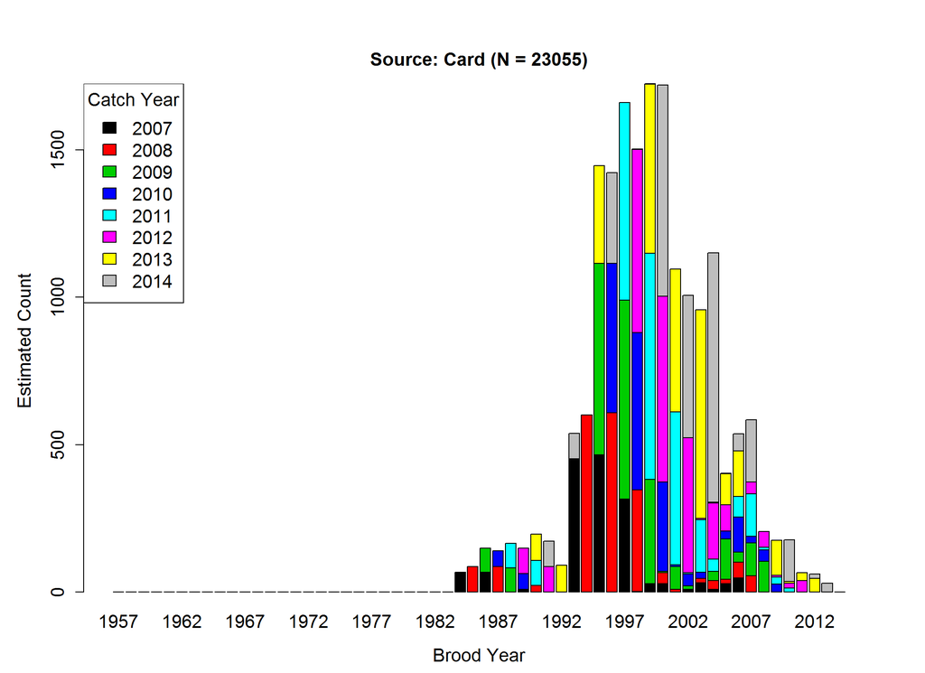

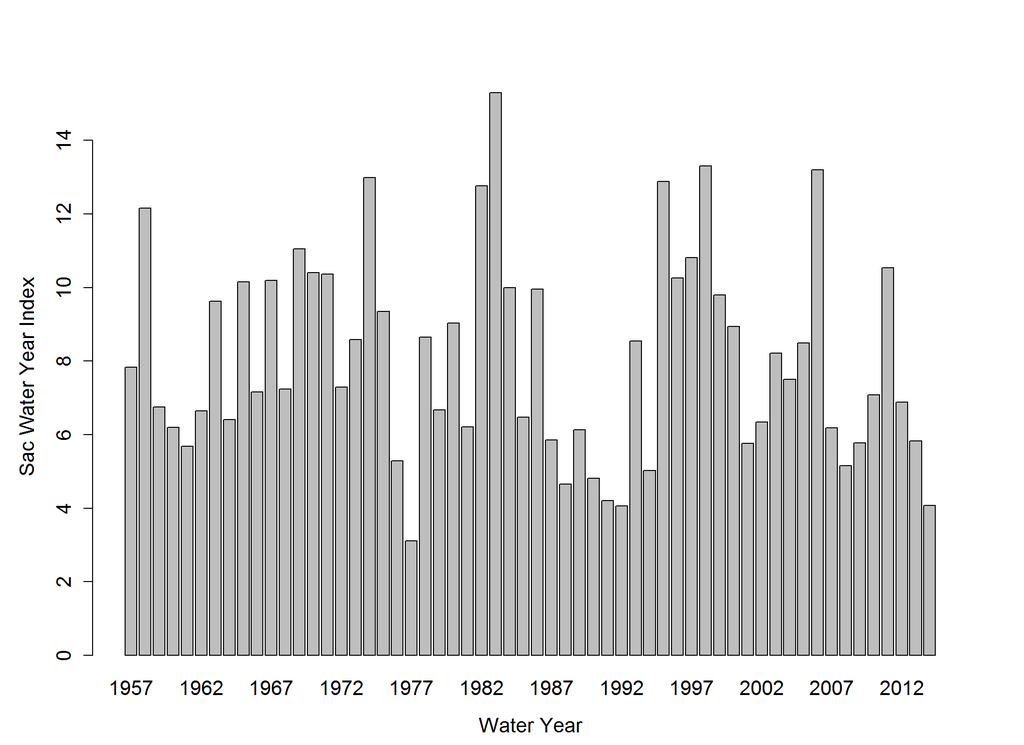

End of report